# Import modules

```python
%%time

%load_ext memory_profiler

import datetime
print(datetime.datetime.now())

import os, glob, sys
import warnings
warnings.filterwarnings('ignore', '.*invalid value encountered in true_divide.*', )

from dask.distributed import Client
from dask.diagnostics import ProgressBar
pbar = ProgressBar(minimum=1)
pbar.register()
#pbar.unregister()

import subprocess

import pickle

import numpy as np
import xarray as xr
import pandas as pd
import matplotlib as mpl
import matplotlib.pyplot as plt

import cartopy.crs       as ccrs
import cartopy
import cartopy.feature as cfeature

import random

import PyCO2SYS

import xesmf as xe

from matplotlib import cm
from matplotlib.colors import ListedColormap

mpl.rcParams['savefig.dpi'] = 300
```

```
2023-10-10 20:06:54.971791
CPU times: user 1.75 s, sys: 2.46 s, total: 4.2 s
Wall time: 2.74 s
```

# Starters

```python
%%time
print(datetime.datetime.now())

dirout = 'cc2300-231009-noresm2-lm-bgc/'
if not os.path.isdir(dirout) : os.mkdir(dirout)
```

```
2023-10-10 20:06:57.698094
CPU times: user 205 µs, sys: 239 µs, total: 444 µs
Wall time: 352 µs
```

```python
%%time
print(datetime.datetime.now())
sys.stdout.echo = open(dirout+'stdout.txt', 'w')
sys.stderr.echo = open(dirout+'stderr.txt', 'w')
```

```
2023-10-10 20:06:57.703683
CPU times: user 0 ns, sys: 429 µs, total: 429 µs
Wall time: 349 µs
```

# Input parameters

```python
%%time
print(datetime.datetime.now())

kwopends=dict(use_cftime=True, decode_times=None,
              decode_cf=True, decode_coords=True)
kwopenmfds = dict(combine='by_coords', parallel=True,
                  use_cftime=True, decode_times=None,
                  decode_cf=True, decode_coords=True)
dircou = 'cc2300-230215-noresm2-lm/'
```

```
2023-10-10 20:06:57.709264
CPU times: user 19 µs, sys: 22 µs, total: 41 µs
Wall time: 47.9 µs
```

# Load NorESM grid

```python
%%time
print(datetime.datetime.now())
fgrid = '/mnt/reef-ns1002k/daco/grid_tnx1v4.nc'
grid  = xr.open_dataset(fgrid)
```

```
2023-10-10 20:06:57.713809
CPU times: user 22.2 ms, sys: 11.2 ms, total: 33.4 ms
Wall time: 38.7 ms
```

# Define figure parameters

```python
%%time
print(datetime.datetime.now())

mpl.rcParams['font.size'] = 8
cm2in = 1/2.54
```

```
2023-10-10 20:06:57.757102
CPU times: user 26 µs, sys: 29 µs, total: 55 µs
Wall time: 57.9 µs
```

# Define some common functions

## mapping function

```python
%%time
print(datetime.datetime.now())

def map_whole_globe(zwdataarray, zwax=None, zwcbShrink=.4, zwcbLabel='', zwcbExtend='both', **pcmkwargs):
    """
    Plot the input DataArray
    zwax are GeoAxes created with cartopy
    e.g.:
        lonlatproj = ccrs.PlateCarree()
        ccrsproj = ccrs.Robinson(central_longitude=-155)
        fig = plt.figure(figsize = (10, 10))
        ax = plt.axes(projection=ccrsproj)
        pcmkwargs = dict(transform=lonlatproj)
        map_whole_globe(zwda, ax, **pcmkwargs)
    if None (default), theyr are created within the function
    """
    print('func: map_whole_globe')

    try:
        pcmkwargs
    except NameError:
        pcmkwargs_exists = False
    else:
        pcmkwargs_exists = True
    #

    XXX = zwdataarray['plon'].values
    YYY = zwdataarray['plat'].values
    ZZZ = zwdataarray.values
    if not zwax is None:
        zwlonlatproj = ccrs.PlateCarree()
        if pcmkwargs_exists:
            if not 'transform' in pcmkwargs: pcmkwargs['transform'] = zwlonlatproj
        else: pcmkwargs={'transform':zwlonlatproj}
        zwpcm = zwax.pcolormesh(XXX, YYY, ZZZ, **pcmkwargs)
    else:
        print("WARNING! zwax is None, create zwfig and zwax")
        zwccrsproj = ccrs.Robinson(central_longitude=-155)
        zwfig = plt.figure(figsize = (10, 10))
        zwax = plt.axes(projection=zwccrsproj)
        zwlonlatproj = ccrs.PlateCarree()
        if pcmkwargs_exists:
            if not 'transform' in pcmkwargs: pcmkwargs['transform'] = zwlonlatproj
        else: pcmkwargs={'transform':zwlonlatproj}
        zwpcm = zwax.pcolormesh(XXX, YYY, ZZZ, **pcmkwargs)
    #
    zwax.add_feature(cfeature.COASTLINE)
    zwax.add_feature(cfeature.LAND)
    zwax.gridlines(draw_labels=True, x_inline=False, y_inline=False,
                   color='k', linestyle='dashed', linewidth=0.5)
    zwax.set_global()

    plt.colorbar(zwpcm, ax=zwax, shrink=zwcbShrink, label=zwcbLabel, extend=zwcbExtend)
    return zwpcm
#

def map_orthographic(zwdataarray, zoombox, \
             zwax=None, zwcbShrink=.4, zwcbLabel='', zwcbExtend='both', **pcmkwargs):
    """
    Plot the input DataArray
    zoombox either indicate the center [clon, clat] of the Orthographic projection (list of 2)
        or the bounds of the projection [lonmin, lonmax, latmin, latmax]
    zwax are GeoAxes created with cartopy
    e.g.:
        lonlatproj = ccrs.PlateCarree()
        ccrsproj = ccrs.Orthographic(central_longitude=-20, central_latitude=-25)
        fig = plt.figure(figsize = (10, 10))
        ax = plt.axes(projection=ccrsproj)
        pcmkwargs = dict(transform=lonlatproj)
        map_whole_globe(zwda, ax, **pcmkwargs)
    if zwax = None (default), they are created within the function
    """
    print('func: map_orthographic')

    try:
        pcmkwargs
    except NameError:
        pcmkwargs_exists = False
    else:
        pcmkwargs_exists = True
    #

    zwlonlatproj = ccrs.PlateCarree()
    if pcmkwargs_exists:
        if not 'transform' in pcmkwargs: pcmkwargs['transform'] = zwlonlatproj
    else: pcmkwargs={'transform':zwlonlatproj}

    if len(zoombox)==4:
        lonmin, lonmax, latmin, latmax = zoombox
        clon, clat = lonmin+.5*(lonmax-lonmin), latmin+.5*(latmax-latmin)
    elif len(zoombox)==2: clon, clat= zoombox
    else: sys.exit('ERROR! Check zoombox, it should be a list of length 2 or 4')

    XXX = zwdataarray['plon'].values
    YYY = zwdataarray['plat'].values
    ZZZ = zwdataarray.values
    if not zwax is None:
        zwpcm = zwax.pcolormesh(XXX, YYY, ZZZ, **pcmkwargs)
    else:
        print("WARNING! zwax is None, create zwfig and zwax")
        zwccrsproj = ccrs.Orthographic(central_longitude=clon, central_latitude=clat)
        zwfig = plt.figure(figsize = (10, 10))
        zwax = plt.axes(projection=zwccrsproj)
        zwpcm = zwax.pcolormesh(XXX, YYY, ZZZ, **pcmkwargs)
    #
    zwax.add_feature(cfeature.COASTLINE)
    zwax.add_feature(cfeature.LAND)
    zwax.gridlines(draw_labels=True, x_inline=False, y_inline=False,
                   color='k', linestyle='dashed', linewidth=0.5)
    if len(zoombox)==4 :
        xmin, _ = zwax.projection.transform_point(lonmin, clat, zwlonlatproj)
        xmax, _ = zwax.projection.transform_point(lonmax, clat, zwlonlatproj)
        _, ymin = zwax.projection.transform_point(clon, latmin, zwlonlatproj)
        _, ymax = zwax.projection.transform_point(clon, latmax, zwlonlatproj)
        zwax.set_extent([xmin,xmax,ymin,ymax], crs=zwax.projection)
    #
    plt.colorbar(zwpcm, ax=zwax, shrink=zwcbShrink, label=zwcbLabel, extend=zwcbExtend)
    return zwpcm
#

def add_gridlines_coastline_and_land(zax):
    print('func: add_gridlines_coastline_and_land')
    import matplotlib.ticker as mticker
    from cartopy.mpl.gridliner import LONGITUDE_FORMATTER, LATITUDE_FORMATTER, LatitudeFormatter, LongitudeFormatter

    zax.add_feature(cfeature.COASTLINE, linewidth=.5)
    zax.add_feature(cfeature.LAND)
    zax.set_global()

    gl = zax.gridlines(draw_labels=['left', 'right'],
                       x_inline=False, y_inline=False,
                       xlocs = mticker.FixedLocator([-120, -60, 0, 60, 120, 180]),
                       xlabel_style = {'size': 'x-small'},
                       ylocs = mticker.FixedLocator([-60, -40, -20, 0, 20, 40, 60]),
                       ylabel_style = {'size': 'x-small'}, dms=True,
                       color='k', linestyle='dashed', linewidth=0.5, alpha=.5)
    # gl.ylocator = mticker.FixedLocator([-60, -40, -20, 0, 20, 40, 60])
    # gl.xlocator = mticker.FixedLocator([-120, -60, 0, 60, 120, 180])
    # gl.top_labels = False
    # gl.bottom_labels = False
    # gl.left_labels = False
    # gl.right_labels = True
    # gl.xlines = True
    # gl.xformatter = LONGITUDE_FORMATTER
    # gl.yformatter = LATITUDE_FORMATTER
    # gl.ylabel_style = {'size': 'x-small'}
    # gl.xlabel_style = {'size': 'x-small'}
    return gl
#
```

```
2023-10-10 20:06:58.082004
CPU times: user 46 µs, sys: 0 ns, total: 46 µs
Wall time: 52.2 µs
```

## Other functions

```python
%%time
print(datetime.datetime.now())

def chunker(seq, size):
    """
    Works with any sequence:

    text = "I am a very, very helpful text"

    for group in chunker(text, 7):
    print(repr(group),)
    # 'I am a ' 'very, v' 'ery hel' 'pful te' 'xt'

    print('|'.join(chunker(text, 10)))
    # I am a ver|y, very he|lpful text

    animals = ['cat', 'dog', 'rabbit', 'duck', 'bird', 'cow', 'gnu', 'fish']

    for group in chunker(animals, 3):
    print(group)
    # ['cat', 'dog', 'rabbit']
    # ['duck', 'bird', 'cow']
    # ['gnu', 'fish']
    """
    return (seq[pos:pos + size] for pos in range(0, len(seq), size))
#

def select_months(zwinp, mmm, verbose=True):
    """
    select_months(zwinp, mmm)
    return month mmm for each year
    mmm is an integer between 1 and 12, january is 1
    zwinp is a DataArray
    """
    if mmm in np.arange(1, 13):
        month_list = ['jan', 'feb', 'mar', 'apr', 'may', 'jun', 'jul', 'aug', 'sep','oct', 'nov', 'dec']
        if verbose: print('func: select_month(%s, %s)'%(zwinp.name, month_list[mmm-1]))
        return zwinp.isel(time=zwinp.groupby('time.month').groups[mmm])
    else: sys.exit('ERROR! The month number (mmm) has to be an integer between 1 and 12')
#

def load_and_concat_hist_ssp(zvar, zscenar, zsavedfile=dirout+'datasave-bgc-phy-noresm2-lm-bgc.pckl', verbose=True):
    if verbose: print('func: load_and_concat_hist_ssp(%s, %s, zsavefile=%s)'%(zvar, zscenar, zsavedfile))
    with open(zsavedfile, 'rb') as f1: loadeddatas = pickle.load(f1)
    if verbose: print("Done, loaded file: "+zsavedfile)
    zwhist = loadeddatas[zvar]['historical']
    zwssp = loadeddatas[zvar][zscenar]
    return xr.concat([zwhist, zwssp], dim='time')
#

def load_hist_ssp_and_select_month(zvar, zscenar, mmm, **kwargs):
    zw = load_and_concat_hist_ssp(zvar, zscenar, **kwargs)
    return select_months(zw, mmm)
#

def load_hist_ssp_and_select_seas(zvar, zscenar, zseas, **kwargs):
    zw = load_and_concat_hist_ssp(zvar, zscenar, **kwargs)
    return select_season(zw, zseas)
#

def select_season(zdat, zseas, verbose=True):
    if verbose: print('func: select_season')
    if zseas == 'JFM':
        output = xr.concat([select_months(zdat, 1, verbose=verbose),
                            select_months(zdat, 2, verbose=verbose),
                            select_months(zdat, 3, verbose=verbose)], 'time').sortby('time').chunk('auto').groupby('time.year').mean(dim='time')
    elif zseas == 'AMJ':
        output = xr.concat([select_months(zdat, 4, verbose=verbose),
                            select_months(zdat, 5, verbose=verbose),
                            select_months(zdat, 6, verbose=verbose)], 'time').sortby('time').chunk('auto').groupby('time.year').mean(dim='time')
    elif zseas == 'JAS':
        output = xr.concat([select_months(zdat, 7, verbose=verbose),
                            select_months(zdat, 8, verbose=verbose),
                            select_months(zdat, 9, verbose=verbose)], 'time').sortby('time').chunk('auto').groupby('time.year').mean(dim='time')
    elif zseas == 'OND':
        output = xr.concat([select_months(zdat, 10, verbose=verbose),
                            select_months(zdat, 11, verbose=verbose),
                            select_months(zdat, 12, verbose=verbose)], 'time').sortby('time').chunk('auto').groupby('time.year').mean(dim='time')
    else: exit('Wrong season name!!! It must be JFM, AMJ, JAS or OND')
    #
    if 'history' in output.attrs: output.attrs['history'] =  'Average on '+zseas + ' ; ' + output.attrs['history']
    else: output.attrs['history'] =  'Average on '+zseas
    return output
#

def NumpyArray_to_DataArray(zwNP, zwrename, zwrefDA, nwattrs={}, force_nwattrs=False):
    """
    Return a DataArray containing the values from the numpy array (zwnp)
    zwrefDA is the reference DataArray for creating the new DataArray
    zwrename to name the new variable in the DataArray
    Attributes from zwrefDA are passed to the returned DataArray
    New attributes can be added passing a dictionnary to nwattrs
    """
    print("func: NumpyArray_to_DataArray")

    zwda = xr.zeros_like(zwrefDA)
    zwda = zwda.rename(zwrename)
    zwda.attrs = zwrefDA.attrs
    for kkk, vvv in nwattrs.items():
        if not kkk in zwrefDA.attrs.keys(): zwda.attrs[kkk]=vvv
        elif kkk in ['description', 'history']: zwda.attrs[kkk] = vvv+' ; '+zwda.attrs[kkk]
        elif force_nwattrs: zwda.attrs[kkk]=vvv
        else: sys.exit('Check nwattrs and zwrefDA.attrs')
    #
    zwda.values = zwNP
    return zwda
#
```

```
2023-10-10 20:06:59.454229
CPU times: user 79 µs, sys: 90 µs, total: 169 µs
Wall time: 149 µs
```

# Load datas

## Load, prepare and save datas in netcdf

```python
%%time
%%memit -c
print(datetime.datetime.now())
print('Load and save datas')
print('Load, prepare and save datas in netcdf')


#######################
# Parameters
#######################

var_list = ['cflx-tot', 'cflx-nat', 'pco2-tot', 'pco2-nat', 'sdic-tot', 'salk-tot', 'sdic-nat', 'salk-nat', 'stemp', 'ssali', 'siconc', 'atmco2']
simu_list = ['historical', 'ssp585']

dirroot = '/mnt/reef-ns1002k-ns2345k/noresm/cases/'
simu_full_names = {'preindustrial': 'N1850_f19_tn14_noresm-dev_RECOUPLING26092019',  # years 3601-3850
                   'historical'   : 'NHISTBGCfrc2_f19_tn14_20220201',                # years 1850-2014
                   'ssp585'       : 'NSSP585BGCfrc2_f19_tn14_20220217',              # years 2015-2100
                   'ssp585-ext'   : 'NSSP585BGCfrc2ext_f19_tn14_20220411'}           # years 2101-2299

var_names = {'cflx-tot': 'co2fxd'      ,
             'cflx-nat': 'natco2fx'    ,
             'pco2-tot': 'pco2'        ,
             'pco2-nat': 'natpco2'     ,
             'sdic-tot': 'dissiclvl'   ,
             'salk-tot': 'talklvl'     ,
             'sdic-nat': 'natdissiclvl',
             'salk-nat': 'nattalklvl'  ,
             'stemp'   : 'sst'         ,
             'ssali'   : 'sss'         ,
             'siconc'  : 'fice'        ,
             'atmco2'  : 'atmco2'      }



kwsubprocess = dict(stdout=subprocess.PIPE, stderr=subprocess.STDOUT, \
                    universal_newlines=True, check=True)

#######################
# Loop on simulations
#######################
print('Loop on simulations...')

for simu in simu_list:

    print('    simu: '+simu)

    fbgc = dirroot + simu_full_names[simu] + '/ocn/hist/' + \
        simu_full_names[simu] + '.blom.hbgcm.*.nc'
    fphy = dirroot + simu_full_names[simu] + '/ocn/hist/' + \
        simu_full_names[simu] + '.blom.hm.*.nc'

    if len(glob.glob(fbgc))==0: sys.exit('ERROR! No files found, check fbgc.')
    if len(glob.glob(fphy))==0: sys.exit('ERROR! No files found, check fphy.')

    fnamebgc = glob.glob(fbgc)
    fnamephy = glob.glob(fphy)

    # simulation extension
    if simu in ['ssp126', 'ssp585']:
        fbgc = dirroot + simu_full_names[simu+'-ext'] + '/ocn/hist/' + \
            simu_full_names[simu+'-ext'] + '.blom.hbgcm.*.nc'
        fphy = dirroot + simu_full_names[simu+'-ext'] + '/ocn/hist/' + \
            simu_full_names[simu+'-ext'] + '.blom.hm.*.nc'
        if len(glob.glob(fbgc))==0: sys.exit('ERROR! No files found for extension, check fbgc.')
        if len(glob.glob(fphy))==0: sys.exit('ERROR! No files found for extension, check fphy.')
        fnamebgc.extend(glob.glob(fbgc))
        fnamephy.extend(glob.glob(fphy))
    #

    print('    Open dataset bgc...')
    zwdsbgc = xr.open_mfdataset(fnamebgc, chunks='auto', **kwopenmfds)
    print('    Done')
    print('    Open dataset phy')
    zwdsphy = xr.open_mfdataset(fnamephy, chunks='auto', **kwopenmfds)
    print('    Done')

    #######################
    # Loop on variables
    #######################
    print('    Loop on variables...')

    for var in var_list:

        print('        var: '+var)

        print('        Load variable...')
        if var=='cflx-tot':
            zwco2fxd = zwdsbgc['co2fxd']
            zwco2fxu = zwdsbgc['co2fxu']
            # air-to-sea carbon flux (positive values = oceanic uptake)
            with xr.set_options(keep_attrs=True): zwda = zwco2fxd - zwco2fxu
        elif (var=='cflx-nat') & (simu=='preindustrial'):
            # print('In preindustrial, cflx-nat = cflx-tot')
            zwco2fxd = zwdsbgc['co2fxd']
            zwco2fxu = zwdsbgc['co2fxu']
            # air-to-sea carbon flux (positive values = oceanic uptake)
            with xr.set_options(keep_attrs=True): zwda = zwco2fxd - zwco2fxu
        elif (var=='cflx-nat') & (simu in ['historical', 'ssp126', 'ssp585']):
            with xr.set_options(keep_attrs=True): zwda = -1*zwdsbgc[var_names[var]]
        elif var in ['sdic-tot', 'salk-tot']:
            # sdic-tot in mol.m-3 or mmol.l-1, salk-tot in m-3
            with xr.set_options(keep_attrs=True): zwda = zwdsbgc[var_names[var]].isel(depth=0)
        elif (var in ['sdic-nat', 'salk-nat']) & (simu=='preindustrial'):
            # print('In preindustrial, dic-nat = dic-tot and alk-nat = alk-tot')
            with xr.set_options(keep_attrs=True): zwda = zwdsbgc[var_names[var.replace('nat', 'tot')]].isel(depth=0)
        elif (var in ['sdic-nat', 'salk-nat']) & (simu in ['historical', 'ssp126', 'ssp585']):
            with xr.set_options(keep_attrs=True): zwda = zwdsbgc[var_names[var]].isel(depth=0)
        elif var in ['pco2-tot', 'atmco2']:
            # pco2 in uatm, atmco2 in ppm
            zwda = zwdsbgc[var_names[var]]
        elif (var=='pco2-nat') & (simu=='preindustrial'):
            # print('In preindustrial, pco2-nat = pco2-tot')
            zwda = zwdsbgc[var_names[var.replace('nat', 'tot')]]
        elif (var=='pco2-nat') & (simu in ['historical', 'ssp126', 'ssp585']):
            zwda = zwdsbgc[var_names[var]]
        elif var in ['stemp', 'ssali', 'siconc']:
            # sst in Celsius, sss in g.kg-1
            zwda = zwdsphy[var_names[var]]
        else: sys.exit('Variable not in the list')
        print('        Done')


        #######################
        # Change variable name
        #######################

        print('        Change variable name...')
        zwda = zwda.rename(var)
        print('        Done')

        zwda.encoding = {}

        #######################
        # Set and save dataset
        #######################
        print('        Set and save dataset...')
        dstosave = zwda.to_dataset()
        if var in ['cflx-tot', 'cflx-nat', 'pco2-tot', 'pco2-nat', 'sdic-tot', 'salk-tot', 'sdic-nat', 'salk-nat', 'atmco2']:
            dstosave.attrs = zwdsbgc.attrs
        elif var in ['stemp', 'ssali', 'siconc']: dstosave.attrs = zwdsphy.attrs
        else: sys.exit('Variable not in the list')
        savedfile = dirout + var + '_noresm2-lm-bgc_' + simu + '.nc'
        dstosave.to_netcdf(savedfile)
        print('        Done')

    #
    print('    Done')
    command = ["touch", dirout+simu.upper()+"-DONE"]
    ppp = subprocess.run(command, **kwsubprocess)
#
print('Done')
print(datetime.datetime.now())
```

```
2023-10-10 20:07:12.900321
Load and save datas
Load, prepare and save datas in netcdf
Loop on simulations...
    simu: historical
    Open dataset bgc...
[########################################] | 100% Completed | 177.98 s
```

## Load and save xarray dataset in a pickle

```python
%%time
print(datetime.datetime.now())
print('Load and save xarray dataset in a pickle')

simu_list = ['historical', 'ssp585']
var_list = ['cflx-tot', 'cflx-nat', 'pco2-tot', 'sdic-tot', 'salk-tot', 'stemp', 'ssali', 'atmco2', 'pco2-nat', 'sdic-nat', 'salk-nat', 'siconc']

#------------------------
# Initialised data2save
#------------------------

data2save = {}
for var in var_list:
    data2save[var] = {}
    for simu in simu_list :
        data2save[var][simu] = {}
    #
#

#------------------------
# Loop on simu
#------------------------

for simu in simu_list:
    print('> simu: '+simu)
    for var in var_list:
        print('>> var: '+var)
        savedfile = dirout+var+'_noresm2-lm-bgc_'+simu+'.nc'
        zwds = xr.open_dataset(savedfile, use_cftime=True, chunks='auto').squeeze() # chunks to use dask array
        data2save[var][simu] = zwds[var]
    #
#

#------------------------
# Save as a pickle
#------------------------

print('> Save as a pickle')
savedfile = dirout+'datasave-bgc-phy-noresm2-lm-bgc.pckl'
if os.path.isfile(savedfile): os.remove(savedfile)
with open(savedfile, 'wb') as f1:pickle.dump(data2save, f1)
print("Done, file saved: "+savedfile)

# ca. 1s
```

# Global mean of tot and nat cflx

```python
%%time
print(datetime.datetime.now())
print('Global mean of tot and nat cflx')

savedfile = dirout+'datasave-bgc-phy-noresm2-lm-bgc.pckl'
with open(savedfile, 'rb') as f1: loadeddatas = pickle.load(f1)
print("Done, loaded file: "+savedfile)

var_list = ['cflx-tot', 'cflx-nat']
#simu_list = ['historical', 'ssp126', 'ssp585']
simu_list = ['historical', 'ssp585']

data2save = {}
for var in var_list:
    print('>> var: '+var)
    data2save[var] = {}
    for simu in simu_list:
        print('>> simu: '+simu)
        data2save[var][simu] = loadeddatas[var][simu].weighted(grid['parea']).mean(dim=('x','y')).compute()
    #
#
print("> Save as pickle")
savedfile = dirout+'cflxtot-cflxnat-global-mean-noresm2-lm-bgc.pckl'
if os.path.isfile(savedfile): os.remove(savedfile)
with open(savedfile, 'wb') as f1:pickle.dump(data2save, f1)
print("Done, file saved: "+savedfile)

# ca. 30s
```

# Running mean and standard deviation of tot and nat cflx

To use it in TOE definition

```python
%%time
%%memit -c
print(datetime.datetime.now())
print('Running mean and standard deviation of tot and nat cflx')

var_list = ['cflx-tot', 'cflx-nat']
simu_list = ['historical', 'ssp585']
month_list = ['jan', 'feb', 'mar', 'apr', 'may', 'jun', 'jul', 'aug', 'sep','oct', 'nov', 'dec']
rolmean = 50

for simu in simu_list:

    print('> simu: '+simu)
    data2save = {}

    for var in var_list:

        print('>> var: '+var)
        data2save[var] = {}

        zwavg_list = []
        zwstd_list = []
        for imonth, month in enumerate(month_list, start=1):
            zw = load_hist_ssp_and_select_month(var, simu, imonth)
            zw2 = zw.rolling(time=rolmean, center=True)
            zwavg_list.append(zw2.mean())
            zwstd_list.append(zw2.std())
        #
        zwavg = xr.concat(zwavg_list, 'time').sortby('time')
        zwstd = xr.concat(zwstd_list, 'time').sortby('time')
        data2save[var] = {'avg':zwavg, 'std':zwstd}

    #
    print("> Save as pickle")
    savedfile = dirout+'cflxtot-cflxnat-running-mean-std-'+str(rolmean)+'y-'+simu+'-noresm2-lm-bgc.pckl'
    if os.path.isfile(savedfile): os.remove(savedfile)
    with open(savedfile, 'wb') as f1:pickle.dump(data2save, f1)
    print("Done, file saved: "+savedfile)
#

# ca. 15s
```

# Running mean and standard deviation of sea ice

To use it in TOE definition

```python
%%time
%%memit -c
print(datetime.datetime.now())
print('Running mean and standard deviation of tot and nat cflx')

var_list = ['siconc']
simu_list = ['historical', 'ssp585']
month_list = ['jan', 'feb', 'mar', 'apr', 'may', 'jun', 'jul', 'aug', 'sep','oct', 'nov', 'dec']
rolmean = 50

for simu in simu_list:

    print('> simu: '+simu)
    data2save = {}

    for var in var_list:

        print('>> var: '+var)
        data2save[var] = {}

        zwavg_list = []
        zwstd_list = []
        for imonth, month in enumerate(month_list, start=1):
            zw = load_hist_ssp_and_select_month(var, simu, imonth)
            zw2 = zw.rolling(time=rolmean, center=True)
            zwavg_list.append(zw2.mean())
            zwstd_list.append(zw2.std())
        #
        zwavg = xr.concat(zwavg_list, 'time').sortby('time')
        zwstd = xr.concat(zwstd_list, 'time').sortby('time')
        data2save[var] = {'avg':zwavg, 'std':zwstd}

    #
    print("> Save as pickle")
    savedfile = dirout+'siconc-running-mean-std-'+str(rolmean)+'y-'+simu+'-noresm2-lm-bgc.pckl'
    if os.path.isfile(savedfile): os.remove(savedfile)
    with open(savedfile, 'wb') as f1:pickle.dump(data2save, f1)
    print("Done, file saved: "+savedfile)
#

# ca. 15s
```

# Fig. 1: time series of carbon flux (total, natural and anth.) and maps of anth. carbon flux

- a) total carbon, average spatially, shading shows monthly variation, historical (bgc), ssp585, ssp585 bgc
- b) Same as before but for Cnat and Cant, add shading for showing time period for the maps
- Maps of Cant average on c) 1990s, d) 2090s SSP585, e) 2290s SSP585, f,g, h) same for BGC
- Adjust colormap so that we see outgassing better (-0.03 to 0.05)

## Load and prepare data to plot

```python
%%time
print(datetime.datetime.now())
print('Fig. 1: load and prepare data to plot')

zfactmod = 3600*24*365/12*1000. # kgC/m2/s -> molC/m2/yr

data2plot = {}

#--------------------
# Timeseries
#--------------------


print('> Timeseries')

data2plot['timeseries'] = {}

#____________________
# Load file with gloabl mean.

savedfile = dircou+'cflxtot-cflxnat-global-mean-noresm2-lm.pckl'
with open(savedfile, 'rb') as f1: cousimudata = pickle.load(f1)
print("Done, loaded file: "+savedfile)

#____________________
# Load bgcsimu global mean computed above
savedfile = dirout+'cflxtot-cflxnat-global-mean-noresm2-lm-bgc.pckl'
with open(savedfile, 'rb') as f1: bgcsimudata = pickle.load(f1)
print("Done, loaded file: "+savedfile)

#____________________
# Loop on variables and simulations

var_list = ['cflx-tot', 'cflx-nat']
simu_list = ['historical', 'ssp585']
for var in var_list:
    print('>> var: '+var)
    data2plot['timeseries'][var] = {}
    for simu in simu_list:
        print('>>> simu:'+simu)
        data2plot['timeseries'][var][simu+'-cou'] = {}
        data2plot['timeseries'][var][simu+'-bgc'] = {}
        # load monthly values
        zwcou = cousimudata[var][simu] * zfactmod
        zwbgc = bgcsimudata[var][simu] * zfactmod
        # monthly values
        yyy = zwcou['time.year']
        mmm = zwcou['time.month']
        data2plot['timeseries'][var][simu+'-cou']['monthly'] = {
            'X': yyy.values + (mmm.values-.5)/12,
            'Y': zwcou.values
        }
        yyy = zwbgc['time.year']
        mmm = zwbgc['time.month']
        data2plot['timeseries'][var][simu+'-bgc']['monthly'] = {
            'X': yyy.values + (mmm.values-.5)/12,
            'Y': zwbgc.values
        }
        # yearly means
        zw = zwcou.groupby('time.year').mean(dim='time')
        data2plot['timeseries'][var][simu+'-cou']['yearly'] = {
            'X': zw['year'].values,
            'Y': zw.values
        }
        zw = zwbgc.groupby('time.year').mean(dim='time')
        data2plot['timeseries'][var][simu+'-bgc']['yearly'] = {
            'X': zw['year'].values,
            'Y': zw.values
        }
    #
#

print('>> Compute anthropogenic carbon flux')
var = 'cflx-ant'
data2plot['timeseries'][var] = {}
for simu in simu_list:
    print('>>> simu:'+simu)
    data2plot['timeseries'][var][simu+'-cou'] = {}
    data2plot['timeseries'][var][simu+'-bgc'] = {}
    for kkk in ['monthly', 'yearly']:
        data2plot['timeseries'][var][simu+'-cou'][kkk] = {
            'X': data2plot['timeseries']['cflx-tot'][simu+'-cou'][kkk]['X'],
            'Y': data2plot['timeseries']['cflx-tot'][simu+'-cou'][kkk]['Y'] - \
                 data2plot['timeseries']['cflx-nat'][simu+'-cou'][kkk]['Y']

        }
        data2plot['timeseries'][var][simu+'-bgc'][kkk] = {
            'X': data2plot['timeseries']['cflx-tot'][simu+'-bgc'][kkk]['X'],
            'Y': data2plot['timeseries']['cflx-tot'][simu+'-bgc'][kkk]['Y'] - \
                 data2plot['timeseries']['cflx-nat'][simu+'-bgc'][kkk]['Y']
        }
    #
#


#--------------------
# Maps
#--------------------

print('> Maps')
data2plot['maps'] = {}

print('>> Load model carbon flux ')
savedfile = dircou+'datasave-bgc-phy-noresm2-lm.pckl'
with open(savedfile, 'rb') as f1: cousimudata = pickle.load(f1)
print("Done, loaded file: "+savedfile)
print('>> Load model carbon flux ')
savedfile = dirout+'datasave-bgc-phy-noresm2-lm-bgc.pckl'
with open(savedfile, 'rb') as f1: bgcsimudata = pickle.load(f1)
print("Done, loaded file: "+savedfile)

Y, X = grid['plat'], grid['plon']

simu   = 'historical'
tslice = slice('1990', '1999')
zwcflx = cousimudata['cflx-tot'][simu] - cousimudata['cflx-nat'][simu]
data2plot['maps']['1990s, COU'] = {'X':X, 'Y':Y, 'Z':zfactmod * zwcflx.sel(time=tslice).mean(dim='time').values}
simu   = 'ssp585'
tslice = slice('2090', '2099')
zwcflx = cousimudata['cflx-tot'][simu] - cousimudata['cflx-nat'][simu]
data2plot['maps']['2090s, COU'] = {'X':X, 'Y':Y, 'Z':zfactmod * zwcflx.sel(time=tslice).mean(dim='time').values}
simu   = 'ssp585'
tslice = slice('2290', '2299')
zwcflx = cousimudata['cflx-tot'][simu] - cousimudata['cflx-nat'][simu]
data2plot['maps']['2290s, COU'] = {'X':X, 'Y':Y, 'Z':zfactmod * zwcflx.sel(time=tslice).mean(dim='time').values}

simu   = 'historical'
tslice = slice('1990', '1999')
zwcflx = bgcsimudata['cflx-tot'][simu] - bgcsimudata['cflx-nat'][simu]
data2plot['maps']['1990s, BGC'] = {'X':X, 'Y':Y, 'Z':zfactmod * zwcflx.sel(time=tslice).mean(dim='time').values}
simu   = 'ssp585'
tslice = slice('2090', '2099')
zwcflx = bgcsimudata['cflx-tot'][simu] - bgcsimudata['cflx-nat'][simu]
data2plot['maps']['2090s, BGC'] = {'X':X, 'Y':Y, 'Z':zfactmod * zwcflx.sel(time=tslice).mean(dim='time').values}
simu   = 'ssp585'
tslice = slice('2290', '2299')
zwcflx = bgcsimudata['cflx-tot'][simu] - bgcsimudata['cflx-nat'][simu]
data2plot['maps']['2290s, BGC'] = {'X':X, 'Y':Y, 'Z':zfactmod * zwcflx.sel(time=tslice).mean(dim='time').values}

data2plot['maps']['1990s, BGC-COU'] = {'X':X, 'Y':Y, 'Z':data2plot['maps']['1990s, BGC']['Z'] - data2plot['maps']['1990s, COU']['Z']}
data2plot['maps']['2090s, BGC-COU'] = {'X':X, 'Y':Y, 'Z':data2plot['maps']['2090s, BGC']['Z'] - data2plot['maps']['2090s, COU']['Z']}
data2plot['maps']['2290s, BGC-COU'] = {'X':X, 'Y':Y, 'Z':data2plot['maps']['2290s, BGC']['Z'] - data2plot['maps']['2290s, COU']['Z']}

print('> Save data2plot')
savedfile = dirout+'data2plot-fig1-bgc.pckl'
if os.path.isfile(savedfile): os.remove(savedfile)
with open(savedfile, 'wb') as f1:pickle.dump(data2plot, f1)
print("Done, file saved: "+savedfile)

# ca. 25s
```

## Plot

```python
%%time
print(datetime.datetime.now())
print('Fig. 1: plot')

#_____________________
# Load data2plot
savedfile = dirout+'data2plot-fig1-bgc.pckl'
with open(savedfile, 'rb') as f1: data2plot = pickle.load(f1)

#---------------------
# FIGURE PARAM
#---------------------

ccrsproj = ccrs.Robinson(central_longitude=-155)
nrow, ncol = 5, 3
#fsize = (ncol*6*cm2in, nrow*4*cm2in)
fsize = (18*cm2in, 16*cm2in)
fig = plt.figure(figsize=fsize)

subnum = list('abcdefghijklmnopqrstuvwxyz')
aaa=[]
for sss in subnum: aaa.append('a'+sss)
subnum=subnum+aaa
subnum.reverse()

#_____________________
# plotting kwargs

kwtimeseries = {
    'cou'         : dict(c='firebrick'),
    'bgc'         : dict(c='dodgerblue'),
    'monthly'     : dict(lw=1, alpha=.2),
    'yearly'      : dict(lw=2),
    'cflx-tot'    : dict(ls='-'),
    'cflx-nat'    : dict(ls='--'),
    'cflx-ant'    : dict(ls='-')
}
ylimits = (-.5, 2)

ncmap = cm.get_cmap('Reds_r', 256)
pcmap = cm.get_cmap('Blues', 256)
nnn = ncmap(np.linspace(0, 1, 3+1))
ppp = pcmap(np.linspace(0, 1, (10-3)+1))
newcolors = np.concatenate([nnn, ppp])
cmap = ListedColormap(newcolors[1:-1])
cmap.set_under(color=newcolors[0])
cmap.set_over(color=newcolors[-1])

kwmaps = {'transform':ccrs.PlateCarree(), 'cmap':cmap, 'vmin':-.9, 'vmax': 2.1}


#---------------------
# Global timeseries
#---------------------

#_____________________
# Total carbon fluxes

iplot = 1

axts1  = fig.add_subplot(nrow, 1, iplot)
axts1.axhline(0, ls='-', lw=1, c='k')
var = 'cflx-tot'
lines, names = [], []
for kkk, vvv in data2plot['timeseries'][var].items():
    for vfreq in ['monthly', 'yearly']:
        X = vvv[vfreq]['X']
        Y = vvv[vfreq]['Y']
        ll, = axts1.plot(X, Y, **{**kwtimeseries[kkk[-3:]], **kwtimeseries[vfreq], **kwtimeseries[var]})
        if (kkk[:10]=='historical') & (vfreq == 'yearly'):
            lines.append(ll)
            names.append(kkk[-3:].upper())
        #
    #
#
axts1.set_title(subnum.pop()+') Global mean C$^{\mathrm{tot}}$ flux', loc='left')
axts1.set_ylabel('[mol$\,$C$\,$m$^{-2}\,$y$^{-1}$]')
axts1.legend(lines, names, handlelength=1, frameon=False, loc='upper left')
axts1.set_xlim((1850, 2300))
axts1.set_ylim(ylimits)
axts1.label_outer()

#_____________________
# Natural and anth. carbon fluxes

iplot = 2
axts2  = fig.add_subplot(nrow, 1, iplot)
axts2.axvspan(1990, 2000, facecolor='lightgray')
axts2.axvspan(2090, 2100, facecolor='lightgray')
axts2.axvspan(2290, 2300, facecolor='lightgray')
axts2.axhline(0, ls='-', lw=1, c='k')
lines, names = [], []

var = 'cflx-nat'
for kkk, vvv in data2plot['timeseries'][var].items():
    for vfreq in ['monthly', 'yearly']:
        X = vvv[vfreq]['X']
        Y = vvv[vfreq]['Y']
        ll, = axts2.plot(X, Y, **{**kwtimeseries[kkk[-3:]], **kwtimeseries[vfreq], **kwtimeseries[var]})
        if (kkk=='historical-bgc') & (vfreq=='yearly'):
            lines.append(ll)
            names.append('C$^{\mathrm{nat}}$')
        #
    #
#
var = 'cflx-ant'
for kkk, vvv in data2plot['timeseries'][var].items():
    for vfreq in ['monthly', 'yearly']:
        X = vvv[vfreq]['X']
        Y = vvv[vfreq]['Y']
        ll, = axts2.plot(X, Y, **{**kwtimeseries[kkk[-3:]], **kwtimeseries[vfreq], **kwtimeseries[var]})
        if (kkk=='historical-bgc') & (vfreq=='yearly'):
            lines.append(ll)
            names.append('C$^{\mathrm{ant}}$')
        #
    #
#
axts2.set_title(subnum.pop()+') Global mean C$^{\mathrm{nat}}$ and C$^{\mathrm{ant}}$ flux', loc='left')
axts2.set_ylabel('[mol$\,$C$\,$m$^{-2}\,$y$^{-1}$]')
axts2.legend(lines, names, handlelength=2, frameon=False, loc='upper left')
axts2.set_xlim((1850, 2300))
axts2.set_ylim(ylimits)
axts2.set_xlabel('Years')

#---------------------
# Maps flux
#---------------------

simu_list = ['1990s, COU', '2090s, COU', '2290s, COU']
iplot = 7
for simu in simu_list:
    vvv=data2plot['maps'][simu]
    zax = fig.add_subplot(nrow, ncol, iplot, projection=ccrsproj)
    X = vvv['X']
    Y = vvv['Y']
    Z = vvv['Z']
    mmm = zax.pcolormesh(X, Y, Z, **kwmaps)
    zax.set_title(subnum.pop()+') ' + simu)
    gl = add_gridlines_coastline_and_land(zax)
    iplot += 1
#

# ax.flat[iplot].set_frame_on(False)
# iplot += 1

simu_list = ['1990s, BGC', '2090s, BGC', '2290s, BGC']
for simu in simu_list:
    vvv=data2plot['maps'][simu]
    zax = fig.add_subplot(nrow, ncol, iplot, projection=ccrsproj)
    X = vvv['X']
    Y = vvv['Y']
    Z = vvv['Z']
    mmm = zax.pcolormesh(X, Y, Z, **kwmaps)
    zax.set_title(subnum.pop()+') ' + simu)
    gl = add_gridlines_coastline_and_land(zax)
    iplot += 1
#

simu_list = ['1990s, BGC-COU', '2090s, BGC-COU', '2290s, BGC-COU']
for simu in simu_list:
    vvv=data2plot['maps'][simu]
    zax = fig.add_subplot(nrow, ncol, iplot, projection=ccrsproj)
    X = vvv['X']
    Y = vvv['Y']
    Z = vvv['Z']
    mmm = zax.pcolormesh(X, Y, Z, **kwmaps)
    zax.set_title(subnum.pop()+') ' + simu)
    gl = add_gridlines_coastline_and_land(zax)
    iplot += 1
#

fig.tight_layout()

#---------------------
# repositionning axes
#---------------------

zw1 = axts1.get_position()
zw2 = axts2.get_position()
nw  = 0.8*zw1.width
nh  = 2.2*zw1.height
nx01 = zw1.x0 + 0.5*(zw1.width - nw)
nx02 = zw2.x0 + 0.5*(zw2.width - nw)
ny02 = zw2.y0
ny01 = zw1.y0 + (ny02-zw2.y0) + (nh-zw2.height) - 0.3*nh
axts1.axes.set_position([nx01, ny01, nw, nh])
axts2.axes.set_position([nx02, ny02, nw, nh])

aspect = 1.6
axmaps = np.reshape(fig.axes[2:], (3, 3))
for zax in axmaps[:, 0]:
    zw = zax.get_position()
    nw = aspect*zw.width
    nh = aspect*zw.height
    zax.axes.set_position([zw.x0, zw.y0+(zw.height-nh), nw, nh])
#
for zax in axmaps[:, 1]:
    zw = zax.get_position()
    nw = aspect*zw.width
    nh = aspect*zw.height
    zax.axes.set_position([zw.x0+(zw.width-nw)/2, zw.y0+(zw.height-nh), nw, nh])
#
for zax in axmaps[:, 2]:
    zw = zax.get_position()
    nw = aspect*zw.width
    nh = aspect*zw.height
    zax.axes.set_position([zw.x0+(zw.width-nw), zw.y0+(zw.height-nh), nw, nh])
#

#---------------------
# Colorbar
#---------------------

zw1 = fig.axes[2].get_position()
zw2 = fig.axes[-1].get_position()
nx0 = zw1.x0 + zw1.width*.5
nw  = zw2.x0 + zw2.width*.5 - nx0
ny0 = zw2.y0 - .5 * zw2.height
nh  = 0.04*nw
cax = fig.add_axes([nx0, ny0, nw, nh])
cbar = fig.colorbar(mmm, cax=cax, extend='both',
                    orientation='horizontal', ticklocation='bottom')
cbar.set_label(label='10 years mean anthropogenic carbon flux [mol$\,$C$\,$m$^{-2}\,$y$^{-1}$]')
cbar.set_ticks(np.linspace(kwmaps['vmin'], kwmaps['vmax'], mmm.cmap.colors.shape[0]+1))


#---------------------
# Save figure
#---------------------

fignam = 'fig-1-bgc.png'
fig.savefig(dirout+fignam, bbox_inches='tight')
print('Done, figure saved: '+fignam)

# ca. 25s
```

# Fig. 2: season and year of ACOD

```python
%%time
print(datetime.datetime.now())
print('Fig. 2: load and prepare data2plot')
print('Inputs')

# zfactmod = 3600*24*365/12*1000. # kgC/m2/s -> molC/m2/yr
month_list = ['jan', 'feb', 'mar', 'apr', 'may', 'jun', 'jul', 'aug', 'sep','oct', 'nov', 'dec']
rolmean=50

#___________________________
# Masks
ocean_mask = xr.where(grid['pmask'].load()==0, False, True)
land_mask  = xr.where(grid['pmask'].load()==0, True, False)
```

### Maps

#### Compute ACOD for each month

```python
%%time
print(datetime.datetime.now())
print('Fig. 3: load and prepare data2plot')
print('Maps: compute ACOD for each month')

simu = 'ssp585'

#___________________________
# Load 50 year running means
print('>> load 50 year running means and std...')
savedfile = dirout+'cflxtot-cflxnat-running-mean-std-'+str(rolmean)+'y-'+simu+'-noresm2-lm-bgc.pckl'
with open(savedfile, 'rb') as f1: loadeddatas = pickle.load(f1)
print("File loaded: "+savedfile)
print('>> load 50 year running means and std for siconc...')
savedfile = dirout+'siconc-running-mean-std-'+str(rolmean)+'y-'+simu+'-noresm2-lm-bgc.pckl'
with open(savedfile, 'rb') as f1: loadeddatas_siconc = pickle.load(f1)
print("File loaded: "+savedfile)

#___________________________
# Compute ACOD for each month
print(">> For each month compute ACOD...")
acod_monthly = []
for imonth, month in enumerate(month_list, start=1):

    zwtot_avg = select_months(loadeddatas['cflx-tot']['avg'], imonth)
    zwtot_std = select_months(loadeddatas['cflx-tot']['std'], imonth)
    zwnat_avg = select_months(loadeddatas['cflx-nat']['avg'], imonth)
    zwsic_avg = select_months(loadeddatas_siconc['siconc']['avg'], imonth)
    # ACOD for each month = minimal year for wich zwtot_avg - zwnat_avg < - zwtot_std
    acod_monthly.append(zwtot_avg['time.year'].where( (zwtot_avg-zwnat_avg<-zwtot_std) & (zwsic_avg<1) ).min(dim='time'))

#
print('Computation done')
# create a xarray for acod_monthly
print('>> Create an xarray...')
acod_monthly = xr.concat(acod_monthly, pd.Index(month_list, name='month')).rename("acod_year")
acod_monthly.attrs['description'] = 'For each month and each grid point, it is the first year when \
the anthropogenic carbon outgassing is stronger than the interannual standard deviation of the total \
air-sea CO2 flux. The anthopogenic carbon flux is the difference between the total and natural carbon \
flux. The carbon fluxes are average on 50 years with a running mean. The interannual standard deviation\
correspond to the standard deviation on these 50 years.'
acod_monthly.attrs['units'] = 'year'
acod_monthly.attrs['simulation'] = simu
acod_monthly.attrs['model'] = 'NorESM2-LM'
acod_monthly.attrs['input file'] = savedfile
print('Done')

# Save in a netcdf
print('>> Save in a netcdf...')
netcdf_name = dirout + 'acod-monthly_noresm2-lm-bgc_'+simu+'.nc'
acod_monthly.to_netcdf(netcdf_name)
print('File saved: '+netcdf_name)



# ca. 4m30
```

#### Compute earliest year of outgassing, month of earliest outgassin and season

```python
%%time
print(datetime.datetime.now())
print('Fig. 2: load and prepare data2plot')
print('Maps: Compute earliest year of outgassing, \
      month of earliest outgassin and season')

data2plot = {}

simu = 'ssp585'

data2plot[simu] = {}


#___________________________
# Load netcdf acod-monthly
print('>> Load netcdf acod-mont...')
netcdf_name = dirout + 'acod-monthly_noresm2-lm-bgc_'+simu+'.nc'
acod_monthly = xr.open_dataset(netcdf_name, chunks='auto', **kwopends)['acod_year'] # chunks to use dask array
print('File loaded: '+netcdf_name)

#___________________________
# Compute yACOD, earliest year of outgassing
print('>> Compute yACOD, earliest year of outgassing...')
yacod = acod_monthly.min(dim='month')
zwnans = xr.apply_ufunc(np.isnan, yacod, dask='allowed')
late_mask  = ocean_mask & zwnans
yacod = xr.where(late_mask, 1e20, yacod)
yacod = xr.where(land_mask, np.nan, yacod)
print('Done')

#___________________________
# Compute mACOD, month of earliest outgassing
print('>> Compute mACOD, month of earliest outgassing...')
zwnans = xr.apply_ufunc(np.isnan, acod_monthly, dask='allowed')
acod_monthly = xr.where(zwnans, 1e20, acod_monthly) # reaplce nan by very high value to get argmin
macod = acod_monthly.argmin(dim='month')
acod_monthly = xr.where(zwnans, np.nan, acod_monthly) # replace back 1e20 by nan
macod = xr.where(land_mask, np.nan, macod)
macod = xr.where(late_mask, 1e20, macod) # replace late values by 1e20
print('Done')

#___________________________
# Compute sACOD, season of earliest outgassing

print('>> Compute sACOD, season of earliest outgassing...')
winter = xr.where((macod==0) | (macod==1)  | (macod==2) , True, False)
spring = xr.where((macod==3) | (macod==4)  | (macod==5) , True, False)
summer = xr.where((macod==6) | (macod==7)  | (macod==8) , True, False)
autumn = xr.where((macod==9) | (macod==10) | (macod==11), True, False)
sacod = xr.zeros_like(macod) + np.nan
sacod = xr.where(winter, 1, np.nan)
sacod = xr.where(spring, 2, sacod)
sacod = xr.where(summer, 3, sacod)
sacod = xr.where(autumn, 4, sacod)
sacod = xr.where(late_mask, 1e20, sacod)  # replace late values by 1e20
sacod = xr.where(land_mask, np.nan, sacod)
print('Done')

#___________________________
# Store in data2plot
print('>> Store in data2plot')
Y, X = grid['plat'], grid['plon']
data2plot[simu]['yACOD'] = {'X':X.values, 'Y':Y.values, 'Z':yacod.values}
data2plot[simu]['sACOD'] = {'X':X.values, 'Y':Y.values, 'Z':sacod.values}


print('> Save data2plot in a pickle...')
savedfile = dirout+'data2plot-fig2.pckl'
if os.path.isfile(savedfile): os.remove(savedfile)
with open(savedfile, 'wb') as f1:pickle.dump(data2plot, f1)
print("File saved: "+savedfile)

# ca. 100ms
```

### Timeseries

```python
%%time
print(datetime.datetime.now())
print('Fig. 2: load and prepare data2plot')
print('timeseries')

tot_oarea = grid['parea'].sum(dim=('x', 'y'))

simu_list = ['ssp585']
data2plot = {}
for simu in simu_list:

    print('> simu')
    data2plot[simu] = {}

    # Fraction of the ocean outgassing carbon each year
    print('>> Load  carbon fluxes...')
    zwtot = load_and_concat_hist_ssp('cflx-tot', simu)
    zwnat = load_and_concat_hist_ssp('cflx-nat', simu)
    zwsic = load_and_concat_hist_ssp('siconc', simu)
    print('Done')
    print('>> Compute fraction of the ocean outgassing carbon each year...')
    # if anth cflux < 0 i.e. outgassing put 1, 0 otherwise
    zw2 = xr.where( (zwtot-zwnat<0) & (zwsic<1), 1, 0)
    zw3 = zw2.groupby('time.year').sum(dim='time') # sum over year
    # if zw3=0, no outgassing anytime of the year so zw4=0, if zw3>0 then outgassing at least one month so zw4=1
    zw4 = xr.where(zw3 > 0, 1, 0)
    zw5 = zw4*grid['parea'] # multiply by ocean cell area to get surface outgassing
    # compute percent of ocean area outgassing at least one month of the year
    frac_oarea_outgas = zw4.weighted(grid['parea']).sum(dim=('x', 'y')) / tot_oarea * 100
    print('Done')

    data2plot[simu]['frac_oarea_outgas'] = {
        'X':frac_oarea_outgas['year'].values,
        'Y':frac_oarea_outgas.values
    }

    # Fraction of the ocean where outgassing carbon emerge each year
    print('>> Load averaged carbon fluxes...')
    savedfile = dirout+'cflxtot-cflxnat-running-mean-std-'+str(rolmean)+'y-'+simu+'-noresm2-lm-bgc.pckl'
    with open(savedfile, 'rb') as f1: loadeddatas = pickle.load(f1)
    print("File loaded: "+savedfile)
    print('>> load 50 year running means and std for siconc...')
    savedfile = dirout+'siconc-running-mean-std-'+str(rolmean)+'y-'+simu+'-noresm2-lm-bgc.pckl'
    with open(savedfile, 'rb') as f1: loadeddatas_siconc = pickle.load(f1)
    print("File loaded: "+savedfile)
    print('>> Compute fraction of the ocean where outgassing carbon emerge each year')
    zwtot_avg = loadeddatas['cflx-tot']['avg']
    zwtot_std = loadeddatas['cflx-tot']['std']
    zwnat_avg = loadeddatas['cflx-nat']['avg']
    zwsic_avg = loadeddatas_siconc['siconc']['avg']
    # if anth cflux avg < - tot std i.e. outgassing put 1, 0 otherwise
    zw2 = xr.where( (zwtot_avg-zwnat_avg<-zwtot_std) & (zwsic_avg<1), 1, 0)
    # sum over year
    zw3 = zw2.groupby('time.year').sum(dim='time')
    # if zw3=0, no outgassing anytime of the year so zw4=0, if zw3>0 then outgassing at least one month so zw4=1
    zw4 = xr.where(zw3 > 0, 1, 0)
    zw5 = zw4*grid['parea'] # multiply by ocean cell area to get surface outgassing
    # compute percent of ocean area outgassing at least one month of the year
    frac_oarea_outgas_emerge = zw4.weighted(grid['parea']).sum(dim=('x', 'y')) / tot_oarea * 100
    print('Done')

    data2plot[simu]['frac_oarea_outgas_emerge'] = {
        'X':frac_oarea_outgas_emerge['year'].values,
        'Y':frac_oarea_outgas_emerge.values
    }
    # replace 25 first and last year by nans
    data2plot[simu]['frac_oarea_outgas_emerge']['Y'][-24:] = np.nan
    data2plot[simu]['frac_oarea_outgas_emerge']['Y'][:24]  = np.nan

#

print('> save file')
savedfile = dirout+'data2plot-fig2-timeseries.pckl'
if os.path.isfile(savedfile): os.remove(savedfile)
with open(savedfile, 'wb') as f1:pickle.dump(data2plot, f1)
print("Done, file saved: "+savedfile)

# ca. 5m
```

## Plot

```
2023-10-11 11:45:29.227411
Fig. 3: plot
func: add_gridlines_coastline_and_land
func: add_gridlines_coastline_and_land
func: add_gridlines_coastline_and_land
func: add_gridlines_coastline_and_land
Done, figure saved: fig-2.png
CPU times: user 17.5 s, sys: 1.93 s, total: 19.5 s
Wall time: 17.3 s
```

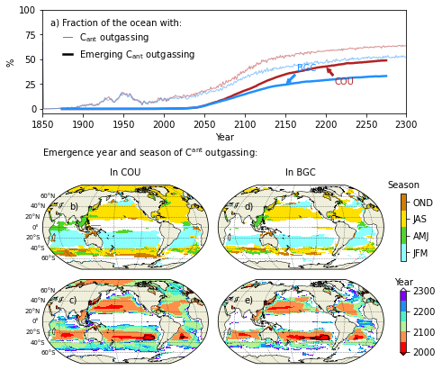

```python
%%time
print(datetime.datetime.now())
print('Fig. 3: plot')

# Load data2plot
savedfile = dirout+'data2plot-fig2.pckl'
with open(savedfile, 'rb') as f1: data2plotbgc = pickle.load(f1)
# Load detectable
savedfile = dirout+'data2plot-fig2-timeseries.pckl'
with open(savedfile, 'rb') as f1: data2plotbgc_ts = pickle.load(f1)

# Load data2plot
savedfile = dircou+'data2plot-fig3.pckl'
with open(savedfile, 'rb') as f1: data2plotcou = pickle.load(f1)
# Load detectable
savedfile = dircou+'data2plot-fig3-timeseries.pckl'
with open(savedfile, 'rb') as f1: data2plotcou_ts = pickle.load(f1)

simu = 'ssp585'

#---------------------
# FIGURE PARAM
#---------------------

nrow, ncol = 3, 2
ccrsproj = ccrs.Robinson(central_longitude=-155)
#fig, ax = plt.subplots(nrow, ncol, figsize=(ncol*4, nrow*3), squeeze=False, subplot_kw=dict(projection=ccrsproj))
fsize = (16*cm2in, 18*cm2in) # width, height
fig = plt.figure(figsize=fsize)

subnum = list('abcdefghijklmnopqrstuvwxyz')
aaa=[]
for sss in subnum: aaa.append('a'+sss)
subnum=subnum+aaa
subnum.reverse()

#---------------------
# PLOTTING KWARGS
#---------------------

from matplotlib import cm
from matplotlib.colors import ListedColormap

# kwmap_year
a = cm.get_cmap('rainbow_r',64)
colors = a(np.linspace(0,1,6))
newcmap = ListedColormap(colors)
newcmap.set_over("white")
newcmap.set_under("darkred")
kwmap_year = dict(transform=ccrs.PlateCarree(), vmin = 2000, vmax = 2300, cmap=newcmap)

# kwmap_seas
colors = np.array([[140/255, 255/255, 255/255, 1.00],
                   [ 79/255, 214/255,  42/255, 1.00],
                   [255/255, 225/255,   0/255, 1.00],
                   [209/255, 125/255,   0/255, 1.00]] )
newcmap = ListedColormap(colors)
newcmap.set_over("white")
kwmap_seas = dict(transform=ccrs.PlateCarree(), vmin = .5, vmax = 4.5, cmap=newcmap)

# kwline_ts
kwline_ts = {
    'BGC'      : dict(c='dodgerblue'),
    'COU'      : dict(c='firebrick')
}

#---------------------
# Plot timeseries area emerged
#---------------------

zax = fig.add_subplot(nrow, 1, 1)

vvv = 'COU'
X = data2plotcou_ts[simu]['frac_oarea_outgas']['X']
Y = data2plotcou_ts[simu]['frac_oarea_outgas']['Y']
ll, = zax.plot(X, Y, ls='-', lw=1., alpha=.5, **kwline_ts[vvv])
ll1, = zax.plot(X, Y*np.nan, label='C$_{\mathrm{ant}}$ outgassing', ls='-', lw=1., alpha=.5, c='black')
X = data2plotcou_ts[simu]['frac_oarea_outgas_emerge']['X']
Y = data2plotcou_ts[simu]['frac_oarea_outgas_emerge']['Y']
ll, = zax.plot(X, Y, ls='-', lw=2.5, **kwline_ts[vvv])
ll2, = zax.plot(X, Y*np.nan, label='Emerging C$_{\mathrm{ant}}$ outgassing', ls='-', lw=2.5, c='black')

vvv= 'BGC'
X = data2plotbgc_ts[simu]['frac_oarea_outgas']['X']
Y = data2plotbgc_ts[simu]['frac_oarea_outgas']['Y']
ll, = zax.plot(X, Y, ls='-', lw=1., alpha=.5, **kwline_ts[vvv])
ll1, = zax.plot(X, Y*np.nan, label='C$_{\mathrm{ant}}$ outgassing', ls='-', lw=1., alpha=.5, c='black')
X = data2plotbgc_ts[simu]['frac_oarea_outgas_emerge']['X']
Y = data2plotbgc_ts[simu]['frac_oarea_outgas_emerge']['Y']
ll, = zax.plot(X, Y, ls='-', lw=2.5, **kwline_ts[vvv])
ll2, = zax.plot(X, Y*np.nan, label='Emerging C$_{\mathrm{ant}}$ outgassing', ls='-', lw=2.5, c='black')

legkwargs={
    'title': subnum.pop()+r') Fraction of the ocean with:         ',
    'frameon': False,
    'handlelength': 1.0
}
zax.legend(handles=[ll1, ll2], **legkwargs)
#zax.set_title()
zax.set_ylabel('%')
zax.set_xlabel('Year')
zax.set_xlim(1850, 2300)
zax.set_ylim(-5, 100)

vvv= 'BGC'
zwx = data2plotbgc_ts[simu]['frac_oarea_outgas_emerge']['X'][-150]
zwy = data2plotbgc_ts[simu]['frac_oarea_outgas_emerge']['Y'][-150]
zax.annotate(vvv, (zwx, zwy), (13, 15), textcoords='offset points', \
             color=kwline_ts[vvv]['c'], \
             arrowprops=dict(arrowstyle='simple',shrinkA=0, \
                             relpos=(0, 0), color=kwline_ts[vvv]['c']))

vvv= 'COU'
zwx = data2plotcou_ts[simu]['frac_oarea_outgas_emerge']['X'][-100]
zwy = data2plotcou_ts[simu]['frac_oarea_outgas_emerge']['Y'][-100]
zax.annotate(vvv, (zwx, zwy), (10, -20), textcoords='offset points', \
             color=kwline_ts[vvv]['c'], \
             arrowprops=dict(arrowstyle='simple',shrinkA=0, \
                             relpos=(0, 1), color=kwline_ts[vvv]['c']))

#---------------------
# Plot maps
#---------------------

iplot = 3
for iii, vvv in enumerate(['COU', 'BGC']):
    fig.add_subplot(nrow, ncol, iplot, projection=ccrsproj)
    iplot+=1
    fig.add_subplot(nrow, ncol, iplot, projection=ccrsproj)
    iplot+=1
#

for iii, vvv in enumerate(['COU', 'BGC']):

    if vvv == 'COU':
        # sACOD
        #zax = fig.add_subplot(nrow, ncol, 1, projection=ccrsproj)
        zax = fig.axes[iii+1]
        X = data2plotcou[simu]['sACOD']['X']
        Y = data2plotcou[simu]['sACOD']['Y']
        Z = data2plotcou[simu]['sACOD']['Z']
        pcm1 = zax.pcolormesh(X, Y, Z, **kwmap_seas)
        gl = add_gridlines_coastline_and_land(zax)
        if iii==1: gl.left_labels=False
        zwtitle = subnum.pop() + ')'
        zax.annotate(zwtitle, (0.16, 0.72),xycoords='axes fraction')

        # yACOD
        #zax = fig.add_subplot(nrow, ncol, 3, projection=ccrsproj)
        zax = fig.axes[iii+1+2]
        X = data2plotcou[simu]['yACOD']['X']
        Y = data2plotcou[simu]['yACOD']['Y']
        Z = data2plotcou[simu]['yACOD']['Z']
        pcm2 = zax.pcolormesh(X, Y, Z, **kwmap_year)

        # yACOD = 2030
        zwX = data2plotcou[simu]['yACOD']['X']
        zwY = data2plotcou[simu]['yACOD']['Y']
        zwZ = data2plotcou[simu]['yACOD']['Z']
        grid_in  = {'lon':zwX, 'lat':zwY}
        ds_out = xe.util.grid_global(1, 1)
        regridder = xe.Regridder(grid_in, ds_out, "bilinear", ignore_degenerate=True, reuse_weights=False)
        Z1 = regridder(zwZ)
        X1, Y1 = ds_out['lon'], ds_out['lat']
        cl = zax.contour(X1, Y1, Z1, levels = [2030], linewidths=1., linestyles='-', colors='k', transform=ccrs.PlateCarree())

        gl = add_gridlines_coastline_and_land(zax)
        if iii==1: gl.left_labels=False
        zwtitle = subnum.pop() + ')'
        zax.annotate(zwtitle, (0.16, 0.72),xycoords='axes fraction')
    #
    if vvv == 'BGC':
        # sACOD
        #zax = fig.add_subplot(nrow, ncol, 1, projection=ccrsproj)
        zax = fig.axes[iii+1]
        X = data2plotbgc[simu]['sACOD']['X']
        Y = data2plotbgc[simu]['sACOD']['Y']
        Z = data2plotbgc[simu]['sACOD']['Z']
        pcm1 = zax.pcolormesh(X, Y, Z, **kwmap_seas)
        gl = add_gridlines_coastline_and_land(zax)
        if iii==1: gl.left_labels=False
        zwtitle = subnum.pop() + ')'
        zax.annotate(zwtitle, (0.16, 0.72),xycoords='axes fraction')

        # yACOD
        #zax = fig.add_subplot(nrow, ncol, 3, projection=ccrsproj)
        zax = fig.axes[iii+1+2]
        X = data2plotbgc[simu]['yACOD']['X']
        Y = data2plotbgc[simu]['yACOD']['Y']
        Z = data2plotbgc[simu]['yACOD']['Z']
        pcm2 = zax.pcolormesh(X, Y, Z, **kwmap_year)

        # yACOD = 2030
        zwX = data2plotbgc[simu]['yACOD']['X']
        zwY = data2plotbgc[simu]['yACOD']['Y']
        zwZ = data2plotbgc[simu]['yACOD']['Z']
        grid_in  = {'lon':zwX, 'lat':zwY}
        ds_out = xe.util.grid_global(1, 1)
        regridder = xe.Regridder(grid_in, ds_out, "bilinear", ignore_degenerate=True, reuse_weights=False)
        Z1 = regridder(zwZ)
        X1, Y1 = ds_out['lon'], ds_out['lat']
        cl = zax.contour(X1, Y1, Z1, levels = [2030], linewidths=1., linestyles='-', colors='k', transform=ccrs.PlateCarree())

        gl = add_gridlines_coastline_and_land(zax)
        if iii==1: gl.left_labels=False
        zwtitle = subnum.pop() + ')'
        zax.annotate(zwtitle, (0.16, 0.72),xycoords='axes fraction')
    #
#

#---------------------
# Repositionning maps axes
#---------------------

fig.tight_layout()

#_____________________
# Lower 1st row of map
for zax in fig.axes[1:3]:
    zw1 = zax.get_position()
    nw  = zw1.width
    nh  = zw1.height
    nx0 = zw1.x0
    ny0 = zw1.y0 - 0.3*zw1.height
    zax.axes.set_position([nx0, ny0, nw, nh])
#
#_____________________
# lift 2nd row of  map
for zax in fig.axes[3:5]:
    zw1 = zax.get_position()
    nw  = zw1.width
    nh  = zw1.height
    nx0 = zw1.x0
    ny0 = zw1.y0 + 0.4*zw1.height
    zax.axes.set_position([nx0, ny0, nw, nh])
#



#---------------------
# Colorbar
#---------------------

hfrac, wfrac = .8, .1

zw1 = fig.axes[2].get_position()
nx0 = zw1.x1 + .1*zw1.width
ny0 = zw1.y0 + (1-hfrac)/2*zw1.height
nh  = hfrac*zw1.height
nw  = wfrac*nh
cax = fig.add_axes([nx0, ny0, nw, nh])
cbar = fig.colorbar(pcm1, cax=cax, orientation='vertical', ticklocation='right',
                    ticks=[1, 2, 3, 4])
cbar.ax.set_yticklabels(['JFM', 'AMJ', 'JAS', 'OND'])  # vertical colorbar
cax.set_title("Season", fontsize='medium')

zw1 = fig.axes[4].get_position()
nx0 = zw1.x1 + .1*zw1.width
ny0 = zw1.y0  + (1-hfrac)/2*zw1.height
nh  = hfrac*zw1.height
nw  = wfrac*nh
cax = fig.add_axes([nx0, ny0, nw, nh])
cbar = fig.colorbar(pcm2, cax=cax, orientation='vertical', ticklocation='right',
                    extend='both')
cax.set_title("Year", fontsize='medium')

#---------------------
# Extra text
#---------------------

# kwtxt = dict(fontsize='large', rotation='horizontal', ha='center', va='bottom')
kwtxt = {"ha": 'left', "va":'bottom'}

zw1 = fig.axes[1].get_position()
nx0 = zw1.x0
ny0 = zw1.y1 + .3*zw1.height
fig.text(nx0, ny0, 'Emergence year and season of C$^{\mathrm{ant}}$ outgassing: ', **kwtxt)

kwtxt = {"ha": 'center', "va":'bottom'}
zw1 = fig.axes[1].get_position()
nx0 = 0.5 *(zw1.x0 + zw1.x1)
ny0 = zw1.y1 + .1*zw1.height
fig.text(nx0, ny0, 'In COU', **kwtxt)

zw1 = fig.axes[2].get_position()
nx0 = 0.5 *(zw1.x0+zw1.x1)
fig.text(nx0, ny0, 'In BGC', **kwtxt)

#---------------------
# Repositionning time series axes
#---------------------

zw1 = fig.axes[1].get_position()
zw2 = fig.axes[-1].get_position()
zw3 = fig.axes[0].get_position()

nx0 = zw1.x0
nw = zw2.x1 - nx0
ny0 = zw3.y0
nh = 0.8*zw3.height
fig.axes[0].axes.set_position([nx0, ny0, nw, nh])

#---------------------
# Save figure
#---------------------

fignam = 'fig-2.png'
fig.savefig(dirout+fignam, bbox_inches='tight')
print('Done, figure saved: '+fignam)

# ca. 17s
```

# Compute CO2 solubilities and schmidt number

## Define functions

```python
%%time
print(datetime.datetime.now())
print('Compute CO2 solubilities and schmidt number')
print('Define functions')

def compute_khd(ptho, psao) :

    """
    Compute solubility of CO2 from Weiss (1974)
    Khd = [CO2]/ p CO2, Weiss (1974), for dry air

    inputs:
        ptho    = temperature [degreeC]
        psao    = salinity    [psu]
    outputs: (Khd) in [mol/l/ppm] and [mol/l/uatm]
        Khd: CO2 solubility for use with partial pressure in moist air
             (no correction for water vapor included) in [mol/l/uatm]
    """

    # Carbon chemistry: Caculate equilibrium constants and solve for [H+] and
    # carbonate alkalinity (ac)

    print('func: comp_khd')

    nans = np.isnan(ptho) | np.isnan(psao)

    tzero   = 273.15
    zw = np.where(ptho>=-3., ptho, -3.)
    tt = np.where(zw<=40., zw, 40.)
    ttk    = tt + tzero
    ttk100 = ttk/100.0

    zw = np.where(psao>=25., psao, 25.)
    ss = np.where(zw<=40., zw, 40.)

    ad1 = -60.2409
    ad2 = 93.4517
    ad3 = 23.3585
    bd1 = 0.023517
    bd2 = -0.023656
    bd3 = 0.0047036

    # Khd = [CO2]/ pCO2 pco2 in seawater
    # Weiss (1974) for dry air [mol/kg/atm]
    nKhwe74 = ad1 + ad2/ttk100 + ad3*np.log(ttk100) + ss*(bd1 + bd2*ttk100 + bd3*ttk100**2)
    Khd     = np.where(nans, np.nan, np.exp(nKhwe74))

    # Khd: CO2 solubility for use with partial pressure in moist air
    #      (no correction for water vapor included) in mol/l/uatm
    return Khd*1e-6
#
def compute_kh(ptho, psao) :

    """
    Compute solubility of CO2 from Weiss (1974)
    Kh = [CO2]/ p CO2, Weiss (1974), refitted for moist air Weiss and Price (1980)

    inputs:
        ptho    = temperature [degreeC]
        psao    = salinity    [psu]
    outputs: (Kh, Khd) in [mol/l/ppm] and [mol/l/uatm]
        Kh: CO2 solubility for use with partial pressure in dry air
            (include correction for accounting for water vapor) in [mol/l/ppm]
    """

    # Carbon chemistry: Caculate equilibrium constants and solve for [H+] and
    # carbonate alkalinity (ac)

    print('func: comp_kh')

    nans = np.isnan(ptho) | np.isnan(psao)

    tzero   = 273.15
    zw = np.where(ptho>=-3., ptho, -3.)
    tt = np.where(zw<=40., zw, 40.)
    ttk    = tt + tzero
    ttk100 = ttk/100.0

    zw = np.where(psao>=25., psao, 25.)
    ss = np.where(zw<=40., zw, 40.)

    ac1 = -162.8301
    ac2 = 218.2968
    ac3 = 90.9241
    ac4 = -1.47696
    bc1 = 0.025695
    bc2 = -0.025225
    bc3 = 0.0049867

    # Kh = [CO2]/ xCO2 dry mole fraction of [CO2]
    # Weiss (1974), refitted for moist air Weiss and Price (1980) [mol/kg/atm]
    nKhwe74 = ac1 + ac2/ttk100 + ac3*np.log(ttk100) + ac4*ttk100**2 + ss*(bc1 + bc2*ttk100 + bc3*ttk100**2)
    Kh     = np.where(nans, np.nan, np.exp(nKhwe74))

    # Kh: CO2 solubility for use with partial pressure in dry air
    #     (include correction for accounting for water vapor) in mol/l/ppm
    return Kh*1e-6
#

def compute_schmidt_number(zwtemp):
    """
    Compute Schmidt number from temperature
    Probably from Sarmiento and Gruber (2006)
    """
    print("func: compute_schmidt_number(zwtemp)")
    Sc = 2116.8 - 136.25*zwtemp + 4.7353*zwtemp**2 - 0.092307*zwtemp**3 +0.0007555*zwtemp**4
    return Sc
#
```

## Computation

```python
%%time
print(datetime.datetime.now())
print('Compute CO2 solubilities and schmidt number')
print('Computation')

simu_list = ['historical', 'ssp585']

for simu in simu_list:

    print('> simu: '+simu)

    print('Load temperature...')
    var = 'stemp'
    ncfile = dirout+var+'_noresm2-lm-bgc_'+simu+'.nc'
    zwds_sst = xr.open_dataset(ncfile, chunks='auto', **kwopends) # chunks to use dask array
    zwda_sst = zwds_sst[var]
    print('Done, file loaded: '+ncfile)

    print('Load salinity...')
    var = 'ssali'
    ncfile = dirout+var+'_noresm2-lm-bgc_'+simu+'.nc'
    zwds_sss = xr.open_dataset(ncfile, chunks='auto', **kwopends) # chunks to use dask array
    zwda_sss = zwds_sss[var]
    print('Done, file loaded: '+ncfile)

    print('Compute Kh...')
    Kh = xr.apply_ufunc(compute_kh, zwda_sst, zwda_sss, dask='allowed')
    Kh = Kh.rename('kh')
    Kh.attrs['comments'] = 'Kh = [CO2]/ xCO2 (xCO2 is dry mole fraction of [CO2]), CO2 solubility for \
    use with partial pressure in dry air (include correction for accounting for water vapor) in \
    mol/l/ppm, Weiss (1974), refitted for moist air Weiss and Price (1980)'
    Kh.attrs['units'] = 'mol l-1 ppm-1'
    Kh.attrs['cell_measures'] = zwda_sst.attrs['cell_measures']
    print('Done')
    print('Save in netcdf...')
    savefile = dirout+'kh_noresm2-lm-bgc_'+simu+'.nc'
    Kh.to_netcdf(savefile)
    print('Done, file saved: '+savefile)

    print('Compute Khd...')
    Khd = xr.apply_ufunc(compute_khd, zwda_sst, zwda_sss, dask='allowed')
    Khd = Khd.rename('khd')
    Khd.attrs['comments'] = 'Khd = [CO2]/ pCO2 (pCO2 is partial pressure of [CO2] in seawater), \
    CO2 solubility for use with partial pressure in moist air (no correction for water vapor \
    included) in mol/l/uatm, Weiss (1974) for dry air [mol/kg/atm]'
    Khd.attrs['units'] = 'mol l-1 uatm-1'
    Khd.attrs['cell_measures'] = zwda_sst.attrs['cell_measures']
    print('Done')
    print('Save in netcdf...')
    savefile = dirout+'khd_noresm2-lm-bgc_'+simu+'.nc'
    Khd.to_netcdf(savefile)
    print('Done, file saved: '+savefile)

    print('Compute Sc...')
    Sc = xr.apply_ufunc(compute_schmidt_number, zwda_sst, dask='allowed')
    Sc = Sc.rename('sc')
    Sc.attrs['comments'] = 'Compute Schmidt number from temperature. Probably \
    from Sarmiento and Gruber (2006).'
    Sc.attrs['cell_measures'] = zwda_sst.attrs['cell_measures']
    print('Done')
    print('Save in netcdf...')
    savefile = dirout+'sc_noresm2-lm-bgc_'+simu+'.nc'
    Sc.to_netcdf(savefile)
    print('Done, file saved: '+savefile)
#

# ca. 4m20s
```

## Load and save xarray dataset in a pickle

```python
%%time
print(datetime.datetime.now())
print('Load and save xarray dataset in a pickle')

simu_list = ['historical', 'ssp585']
var_list = ['kh', 'khd', 'sc']

#------------------------
# Initialised data2save
#------------------------

data2save = {}
for var in var_list:
    data2save[var] = {}
    for simu in simu_list :
        data2save[var][simu] = {}
    #
#

#------------------------
# Loop on simu
#------------------------

for simu in simu_list:
    print('> simu: '+simu)
    for var in var_list:
        print('>> var: '+var)
        ncfile = dirout+var+'_noresm2-lm-bgc_'+simu+'.nc'
        data2save[var][simu] = xr.open_dataset(ncfile, chunks='auto', **kwopends)[var] # chunks to use dask array
    #
#

#------------------------
# Save as a pickle
#------------------------

print('> Save as a pickle')
savedfile = dirout+'datasave-kh-khd-sc-noresm2-lm-bgc.pckl'
if os.path.isfile(savedfile): os.remove(savedfile)
with open(savedfile, 'wb') as f1:pickle.dump(data2save, f1)
print("Done, file saved: "+savedfile)

# ca. 1s
```

# Fig. 3: taylor expansion for SSP585 dpCO2/dt = thermal trends + carbon trends + FW trends

\begin{align} \frac{\mathrm{d}pCO_2}{\mathrm{d}t} =&&& \frac{\overline{pCO_2} \times \overline{S}}{\gamma_C \times S_0} \times \frac{\partial C_s}{\partial t} + \frac{\overline{pCO_2} \times \overline{S}}{\gamma_A \times S_0} \times \frac{\partial A_s}{\partial t} && {\rm \bf Carbon\ system} \\ &+&& \overline{pCO_2} \times \gamma_T \times \frac{\partial T}{\partial t} && {\rm \bf Thermal} \\ &+&& \left( \frac{\overline{pCO_2} \times \overline{C_s}}{\gamma_C \times S_0} + \frac{\overline{pCO_2} \times \overline{A_s}}{\gamma_A \times S_0} + \frac{\overline{pCO_2} \times \gamma_S}{\overline{S}} \right) \times \frac{\partial S}{\partial t} && {\rm \bf Freshwater\ and\ salinity} \end{align}

with:

- $\overline{X}$ is the mean of $X$ over the time period considered
- $\partial X / \partial t $ is the trend of $X$ over the time period considered
- $C_s$ and $A_s$ DIC and ALK normalized with salinity: $X_s = S_0/S \times X$. $S_0$ is the temporal average of $S$ all over the simulation.
- $\gamma_C$ and $\gamma_A$ computed with pyCO2SYS, $\partial pCO_2/\partial X = pCO_2/\gamma_X$
- $\gamma_T = 0.0423$, $\gamma_S = 1$

## Full

1. Compute the taylor expansion for the full ocean for the different season considered
2. Prepare a pickle with the data2plot

### Compute taylor expansion

1. Load pCO2, Khd, Kh, sdic, salk, sss, sst
2. Compute pCO2 * Khd / Kh and Salinity normalized DIC and ALK
3. Loop on season:
   1. Select season
   2. Compute mean and trends
   3. Compute taylor expansion coefficient
   4. Compute taylor expansion terms
   5. Compute main terms: pco2 trend, carbon system trend, thermal trend and freshwater trend

Save Data

- main terms: *dirout+'taylor_expansion_analysis*noresm2-lm*'+simu+'_'+seas+'.nc'*
- time running means: *dirout+'taylor_expansion_analysis_time_running_means*noresm2-lm*'+simu+'_'+seas+'.nc'*
- trends: *dirout+'taylor_expansion_analysis_trends*noresm2-lm*'+simu+'_'+seas+'.nc"*
- coefficients: *dirout+'taylor_expansion_analysis_coefficient*noresm2-lm*'+simu+'_'+seas+'.nc'*
- taylor terms: *dirout+'taylor_expansion_analysis_terms*noresm2-lm*'+simu+'_'+seas+'.nc'*
- Reference salinity: *dirout+'taylor_expansion_analysis_SSS0*noresm2-lm*'+simu+'_'+seas+'.nc'*

#### Starters

```python
#----------------
# PARAMETERS
#----------------

simu = 'ssp585'
seas_list  = ['JAS', 'JFM']
nbyear = 50 # number of year to compute the mean and trends

#----------------
# Define fuction
#----------------

def savedatatonetcdf(zwdict, zwfile, zwcomment=''):
    print('Save in netcdf...')
    tods = {}
    for kkk, vvv in zwdict.items():
        tods[vvv.name] = vvv
    #
    dstosave = xr.Dataset(tods)
    dstosave.attrs['simu'] = 'historical and '+simu
    dstosave.attrs['model'] = 'NorESM2-LM'
    try: dstosave.attrs['comment'] = zwcomment+' ; '+ dstosave.attrs['comment']
    except: dstosave.attrs['comment'] = zwcomment
    dstosave.to_netcdf(zwfile)
    print('Done, file saved: '+zwfile)
#
```

#### Step 1, 2, 3A and 3B

```python
%%time
%%memit -c

print(datetime.datetime.now())
print('Fig. 3: taylor expansion for SSP585 dpCO2/dt = thermal trends + carbon trends + FW trends')
print("Full ocean: compute taylor expansion: step 1, 2, 3A and 3B")


#=======================================
# 1 - Load pCO2, Khd, Kh, sdic, salk, sss, sst, atmco2
# 1bis - Select grid points
#=======================================

print('Load pCO2, Khd, Kh, sdic, salk, sss, sst, atmco2 and select grid point...')
var_list = ['pco2-tot', 'kh', 'khd', 'sdic-tot', 'salk-tot', 'stemp', 'ssali', 'atmco2']
zwdata = {}
for var in var_list:
    if var in ['kh', 'khd']:
        zw = load_and_concat_hist_ssp(var, simu, \
                                           zsavedfile=dirout+'datasave-kh-khd-sc-noresm2-lm-bgc.pckl')
    else: zw = load_and_concat_hist_ssp(var, simu)
    zwplat = grid['plat']
    zwplon = grid['plon']
    zw = zw.assign_coords(dict(plat=zwplat, plon=zwplon))
    try: del zw.attrs['actual_range']
    except: pass
    zwdata[var] = zw
#
print('Done')

#=======================================
# 2 - Compute pco2-atm and salinity normalized DIC and ALK
#=======================================

print('Compute pCO2-atm and salinity normalized DIC and ALK...')

# pco2-atm = atmco2 * Kh / Khd
# because fgco2 = ( atco2  - xco2 ) * Kh * 1e-6 * kwco2 * dtbgc * rrho
# and xco2 = cu * 1.e6 / Kh (dry mole fraction of CO2)
# and pco2 = cu * 1.e6 / Khd (pco2 in seawater)
# thus fgco2 = ( atco2 - pco2 * Khd / Kh ) * Kh * 1e-6 * kwco2 * dtbgc * rrho
# thus fgco2 = ( atco2 * Kh / Khd - pco2 ) * Khd * 1e-6 * kwco2 * dtbgc * rrho
zw = ( zwdata['atmco2'] * zwdata['kh'] / zwdata['khd'] ).rename('pco2-atm')
zw.attrs = zwdata['atmco2'].attrs
addtxt = 'pco2-atm = atmco2 * Kh / Khd because fgco2 = ( atco2 * Kh / Khd - pco2 ) * Khd * 1e-6 * kwco2 * dtbgc * rrho '
try: zw.attrs['history'] = addtxt+' ; '+zw.attrs['history']
except: zw.attrs['history'] = addtxt
zwdata['pco2-atm'] = zw

SSS0 = zwdata['ssali'].mean(dim='time', keep_attrs=True)
addtxt = 'Temporal mean over ' + \
str(zwdata['ssali']['time.year'].min().values) +'-'+\
str(zwdata['ssali']['time.year'].max().values)
try : SSS0.attrs['history'] = addtxt+' ; ' + SSS0.attrs['history']
except : SSS0.attrs['history'] = addtxt
addtxt = 'Reference salinity used for normalizing DIC and ALK '
try : SSS0.attrs['comment'] = addtxt+' ; ' + SSS0.attrs['comment']
except : SSS0.attrs['comment'] = addtxt
for var in ['sdic-tot', 'salk-tot']:
    zw = ( zwdata[var]*SSS0/zwdata['ssali'] ).rename(var+'-sn')
    zw.attrs = zwdata[var].attrs
    try: zw.attrs['long_name'] = zwdata[var].attrs['long_name'] + ' salinity normalized'
    except: zw.attrs['long_name'] = var + ' salinity normalized'
    addtxt = 'salinity normalization %s * SSS0 / sss. SSS0 is a reference \
    salinity, here time average. sss is sea surface salinity'%var.upper()
    try : zw.attrs['history'] = addtxt+' ; ' + zw.attrs['history']
    except : zw.attrs['history'] = addtxt
    zwdata[var+'-sn'] = zw
#
print('Done')

#_________________
# Save SSS0
savefile = dirout+'taylor_expansion_analysis_SSS0_noresm2-lm-bgc_'+simu+'.nc'
SSS0.to_netcdf(savefile)

# remove unnnecessary variables
for vvv in ['atmco2', 'kh', 'khd']: del zwdata[vvv]


#=======================================
# 3 - Loop on season
#=======================================
print('Start loop on season')
for seas in seas_list:

    print('> Season: '+seas)

    #----------------
    # A - Select season
    #----------------

    print('Select season...')
    zwdata2 = {}
    for kkk, vvv in zwdata.items():
        zwdata2[kkk] = select_season(vvv, seas, verbose=False)
    #
    print('Done')

    #----------------
    # B - Compute mean and trends
    #----------------

    zwavg = {}
    zwtrd = {}
    zfact_alk_dic = 1000./1.024 # from mol.m-3 to umol.kg-1
    var_list = ['pco2-tot', 'sdic-tot', 'salk-tot', 'sdic-tot-sn', 'salk-tot-sn', 'stemp', 'ssali', 'pco2-atm']
    for var in var_list:

        # Average
        print('Compute mean of '+var+'...')
        zw = zwdata2[var].rolling(year=nbyear, center=True).mean()
        if var in ['sdic-tot', 'salk-tot', 'sdic-tot-sn', 'salk-tot-sn']:
            with xr.set_options(keep_attrs=True): zw = zw*zfact_alk_dic # in umol.kg-1
            zw.attrs['units'] = 'umol kg-1'
        #
        try: zw.attrs['history'] = 'Running mean on '+str(nbyear)+' years ; '+ zw.attrs['history']
        except: zw.attrs['history'] = 'Running mean on '+str(nbyear)+' years'
        zwavg[var] = zw
        print('Done')

        # Trends
        print('Compute trend of '+var+'...')
        zw_shift = xr.apply_ufunc(np.roll, zwavg[var], nbyear, kwargs=dict(axis=0), dask='allowed', keep_attrs=True)
        zw = xr.apply_ufunc(np.roll, (zwavg[var] - zw_shift)/nbyear, -int(nbyear/2), kwargs=dict(axis=0), dask='allowed', keep_attrs=False)
        zw[0] = np.nan
        zw.attrs = zwavg[var].attrs
        zw = zw.rename(var+'-trd')
        try: zw.attrs['long_name'] = 'Trend of '+zwavg[var].attrs['long_name']
        except: zw.attrs['long_name'] = 'Trend of '+var
        try: zw.attrs['units'] = zw.attrs['units'] + ' y-1'
        except: zw.attrs['units'] = 'y-1'
        addtxt = 'Trend computed as the difference between 2 consecutive time period of '+str(nbyear)+' years'
        try: zw.attrs['history'] = addtxt+' ; '+ zw.attrs['history']
        except: zw.attrs['history'] = addtxt
        zwtrd[var] = zw
        print('Done')
    #
    del zwdata2

    #________________
    # Save data to netcdf

    comment = 'This netcdf contains time running means used for the taylor expansion analysis'
    savefile = dirout+'taylor_expansion_analysis_time_running_means_noresm2-lm-bgc_'+simu+'_'+seas+'.nc'
    savedatatonetcdf(zwavg, savefile, zwcomment=comment)

    comment = 'This netcdf contains the trends used for the taylor expansion analysis'
    savefile = dirout+'taylor_expansion_analysis_trends_noresm2-lm-bgc_'+simu+'_'+seas+'.nc'
    savedatatonetcdf(zwtrd, savefile, zwcomment=comment)
#
del zwtrd, zwavg, zw, zw_shift, zwdata
print('End loop on season')
#=======================================
# END 3 - Loop on season
#=======================================

# ca. 2m40s
```

#### Step 3C

```python
%%time
%%memit -c
print(datetime.datetime.now())
print('Fig. 3: taylor expansion for SSP585 dpCO2/dt = thermal trends + carbon trends + FW trends')
print("Full ocean: compute taylor expansion: step 3C")

#=======================================
# 3 - Loop on season
#=======================================
print('Start loop on season')
for seas in seas_list:

    print('> Season: '+seas)

    #________________
    # Reload zwavg from netcdf
    savefile = dirout+'taylor_expansion_analysis_time_running_means_noresm2-lm-bgc_'+simu+'_'+seas+'.nc'
    zwavg = xr.open_dataset(savefile, **kwopends, chunks='auto')
    savefile = dirout+'taylor_expansion_analysis_SSS0_noresm2-lm-bgc_'+simu+'.nc'
    SSS0 = xr.open_dataset(savefile, **kwopends, chunks='auto')['ssali']


    #----------------
    # C - Compute taylor expansion coefficient
    #----------------

    print('Compute taylor expansion coefficient...')
    cut=30
    zwgam_np = {}
    var_list = ['sdic-tot', 'salk-tot', 'sdic-tot-sn', 'salk-tot-sn', 'sdic-tot-fw', 'salk-tot-fw']
    for var in var_list:
        zwgam_np[var] = []
    for yyy in zwavg['salk-tot'].year.values[::cut]:
        sss = slice(yyy, yyy+cut-1)
        print('    Run PyCO2SYS on years %d-%d...'%(sss.start, sss.stop))
        zwalk    = zwavg['salk-tot'   ].sel(year=sss)
        zwdic    = zwavg['sdic-tot'   ].sel(year=sss)
        zwalk_sn = zwavg['salk-tot-sn'].sel(year=sss)
        zwdic_sn = zwavg['sdic-tot-sn'].sel(year=sss)
        zwsss    = zwavg['ssali'      ].sel(year=sss)
        zwsst    = zwavg['stemp'      ].sel(year=sss)
        kwargs = dict(par1=zwalk, par2=zwdic, par1_type=1, par2_type=2,
                      salinity=zwsss, temperature=zwsst, opt_pH_scale=1,
                      opt_k_carbonic=4, opt_k_bisulfate=1)
        zwco2sysres = xr.apply_ufunc(PyCO2SYS.sys, kwargs=kwargs, dask='allowed')
        # coef-dic
        var = 'sdic-tot'
        zwgam_np[var] .extend( 1 / (zwco2sysres['gamma_dic'] * 1e6) )
        # coef-alk
        var = 'salk-tot'
        zwgam_np[var] .extend( 1 / (zwco2sysres['gamma_alk'] * 1e6) )
        # coef-dic-sn
        var = 'sdic-tot-sn'
        zwgam_np[var] .extend( zwsss/SSS0 * 1 / (zwco2sysres['gamma_dic'] * 1e6) )
        # coef-alk-sn
        var = 'salk-tot-sn'
        zwgam_np[var] .extend( zwsss/SSS0 * 1 / (zwco2sysres['gamma_alk'] * 1e6) )
        # coef-dic-fw
        var = 'sdic-tot-fw'
        zwgam_np[var] .extend( zwdic_sn/SSS0 * 1 / (zwco2sysres['gamma_dic'] * 1e6) )
        # coef-alk-fw
        var = 'salk-tot-fw'
        zwgam_np[var] .extend( zwalk_sn/SSS0 * 1 / (zwco2sysres['gamma_alk'] * 1e6) )
        print('    Done')
    #
    del zwalk, zwdic, zwalk_sn, zwdic_sn, zwsss, zwsst
    for var in var_list: zwgam_np[var] = np.array(zwgam_np[var])

    print('    Set coefficient as dataarray...')

    zwgam = {}
    # coef-dic
    var = 'sdic-tot'
    addtxt = "Taylor expansion coefficient computed with PyCO2SYS, 1 / (zwco2sysres['gamma_dic'] * 1e6)"
    nwattrs = dict(long_name=var+' coefficient for taylor expansion', units='l umol-1',
                   history=addtxt)
    zwgam[var] = NumpyArray_to_DataArray(zwgam_np[var], 'coef-'+var, zwavg['stemp'], nwattrs=nwattrs, force_nwattrs=True)

    # coef-alk
    var = 'salk-tot'
    addtxt = "Taylor expansion coefficient computed with PyCO2SYS, 1 / (zwco2sysres['gamma_alk'] * 1e6)"
    nwattrs = dict(long_name='ALK coefficient for taylor expansion', units='l umol-1',
                  history=addtxt)
    zwgam[var]    =  NumpyArray_to_DataArray(zwgam_np[var], 'coef-'+var, zwavg['stemp'], nwattrs=nwattrs, force_nwattrs=True)

    # coef-dic-sn
    var = 'sdic-tot-sn'
    addtxt = "Taylor expansion coefficient computed with PyCO2SYS, zwavg['ssali']/SSS0 * 1 / (zwco2sysres['gamma_dic'] * 1e6)"
    nwattrs = dict(long_name='DIC-sn coefficient for taylor expansion', units='l umol-1',
                  history=addtxt)
    zwgam[var]    = NumpyArray_to_DataArray(zwgam_np[var], 'coef-'+var, zwavg['stemp'], nwattrs=nwattrs, force_nwattrs=True)

    # coef-alk-sn
    var = 'salk-tot-sn'
    addtxt = "Taylor expansion coefficient computed with PyCO2SYS, zwavg['ssali']/SSS0 * 1 / (zwco2sysres['gamma_alk'] * 1e6)"
    nwattrs = dict(long_name='ALK-sn coefficient for taylor expansion', units='l umol-1',
                  history=addtxt)
    zwgam[var]    = NumpyArray_to_DataArray(zwgam_np[var], 'coef-'+var, zwavg['stemp'], nwattrs=nwattrs, force_nwattrs=True)

    # coef-dic-fw
    var = 'sdic-tot-fw'
    addtxt = "Taylor expansion coefficient computed with PyCO2SYS, zwavg['sdic-tot-sn']/SSS0 * 1 / (zwco2sysres['gamma_dic'] * 1e6)"
    nwattrs = dict(long_name='DIC-fw coefficient for taylor expansion', units='l umol-1',
                  history=addtxt)
    zwgam[var]    = NumpyArray_to_DataArray(zwgam_np[var], 'coef-'+var, zwavg['stemp'], nwattrs=nwattrs, force_nwattrs=True)

    # coef-alk-fw
    var = 'salk-tot-fw'
    addtxt = "Taylor expansion coefficient computed with PyCO2SYS, zwavg['salk-tot-sn']/SSS0 * 1 / (zwco2sysres['gamma_alk'] * 1e6)"
    nwattrs = dict(long_name='ALK-fw coefficient for taylor expansion', units='l umol-1',
                  history=addtxt)
    zwgam[var]    = NumpyArray_to_DataArray(zwgam_np[var], 'coef-'+var, zwavg['stemp'], nwattrs=nwattrs, force_nwattrs=True)

    # coef-sst
    var = 'stemp'
    zwda = xr.where(zwavg['stemp'].isnull(), np.nan, 0.0423 * xr.ones_like(zwavg['stemp']))
    zwda = zwda.rename('coef-'+var)
    zwda.attrs = zwavg['stemp'].attrs
    zwda.attrs['long_name'] = 'SST coefficient for taylor expansion'
    zwda.attrs['units'] = 'degC-1'
    addtxt = "Taylor expansion coefficient 0.0423"
    try: zwda.attrs['history'] = addtxt+' ; '+ zwda.attrs['history']
    except: zwda.attrs['history'] = addtxt
    zwgam[var]       = zwda

    # coef-sss
    var = 'ssali'
    zwda = 1 / zwavg['ssali']
    zwda = zwda.rename('coef-'+var)
    zwda.attrs = zwavg['ssali'].attrs
    zwda.attrs['long_name'] = 'SSS coefficient for taylor expansion'
    zwda.attrs['units'] = 'kg g-1'
    addtxt = "Taylor expansion coefficient 1 / zwavg['ssali']"
    try: zwda.attrs['history'] = addtxt+' ; '+ zwda.attrs['history']
    except: zwda.attrs['history'] = addtxt
    zwgam[var]       = zwda

    print('    Done')

    print('Done')

    #________________
    # Save data to netcdf

    comment = 'This netcdf contains the coefficient used for the taylor expansion analysis. \
    The coefficient are multiply by the average pCO2 and the trend to get the different terms of the taylor expansion'
    savefile = dirout+'taylor_expansion_analysis_coefficient_noresm2-lm-bgc_'+simu+'_'+seas+'.nc'
    savedatatonetcdf(zwgam, savefile, zwcomment=comment)


#
del zwavg, zwgam, zwda
print('End loop on season')
#=======================================
# END 3 - Loop on season
#=======================================

# ca. 20m
```

#### Step 3D

```python
%%time
%%memit -c
print(datetime.datetime.now())
print('Fig. 3: taylor expansion for SSP585 dpCO2/dt = thermal trends + carbon trends + FW trends')
print("Full ocean: compute taylor expansion: step 3D")

#=======================================
# 3 - Loop on season
#=======================================
print('Start loop on season')
for seas in seas_list:

    print('> Season: '+seas)

    #________________
    # Reload zwavg, zwtrd, zwgam from netcdf

    savefile = dirout+'taylor_expansion_analysis_time_running_means_noresm2-lm-bgc_'+simu+'_'+seas+'.nc'
    zwavg = xr.open_dataset(savefile, chunks = 'auto', **kwopends)
    savefile = dirout+'taylor_expansion_analysis_trends_noresm2-lm-bgc_'+simu+'_'+seas+'.nc'
    zwtrd = xr.open_dataset(savefile, chunks = 'auto', **kwopends)
    savefile = dirout+'taylor_expansion_analysis_coefficient_noresm2-lm-bgc_'+simu+'_'+seas+'.nc'
    zwgam = xr.open_dataset(savefile, chunks = 'auto', **kwopends)


    #----------------
    # D - Compute taylor expansion terms
    #----------------

    print('Compute taylor expansion terms...')
    zwtaylor = {}
    var_list = ['stemp', 'ssali', 'sdic-tot', 'salk-tot', 'sdic-tot-sn', 'salk-tot-sn']
    for var in var_list:

        zwda = zwavg['pco2-tot'] * zwgam['coef-'+var] * zwtrd[var+'-trd']
        zwda.attrs = zwgam['coef-'+var].attrs
        zwda = zwda.rename('taylor-term-'+var)
        zwda.attrs['long_name'] = var+' term for taylor expansion'
        zwda.attrs['units'] = zwavg['pco2-tot'].attrs['units']+' y-1'
        addtxt = var.upper() + " taylor expansion term: zwavg['pco2-tot'] * zwgam['coef-'+var] * zwtrd[var+'-trd']"
        try: zwda.attrs['history'] = addtxt+' ; '+ zwda.attrs['history']
        except: zwda.attrs['history'] = addtxt
        zwtaylor[var] = zwda

    #
    for var in ['sdic-tot-fw', 'salk-tot-fw']:
        zwda = zwavg['pco2-tot'] * zwgam['coef-'+var] * zwtrd['ssali-trd']
        zwda.attrs = zwgam['coef-'+var].attrs
        zwda = zwda.rename('taylor-term-'+var)
        zwda.attrs['long_name'] = var+' term for taylor expansion'
        zwda.attrs['units'] = zwavg['pco2-tot'].attrs['units'] +' y-1'
        addtxt = var.upper() + " taylor expansion term: zwavg['pco2-tot'] * zwgam['coef-'+var] * zwtrd['ssali-trd']"
        try: zwda.attrs['history'] = addtxt+' ; '+ zwda.attrs['history']
        except: zwda.attrs['history'] = addtxt
        zwtaylor[var] = zwda
    #
    print('Done')

    #________________
    # Save data to netcdf

    comment = 'This netcdf contains the different terms used for the taylor expansion analysis.'
    savefile = dirout+'taylor_expansion_analysis_terms_noresm2-lm-bgc_'+simu+'_'+seas+'.nc'
    savedatatonetcdf(zwtaylor, savefile, zwcomment=comment)


#
del zwavg, zwtrd, zwgam, zwtaylor, zwda
print('End loop on season')
#=======================================
# END 3 - Loop on season
#=======================================

# ca. 30s
```

#### Step 3E

```python
%%time
print(datetime.datetime.now())
print('Fig. 3: taylor expansion for SSP585 dpCO2/dt = thermal trends + carbon trends + FW trends')
print("Full ocean: compute taylor expansion: step 3E")

#=======================================
# 3 - Loop on season
#=======================================
print('Start loop on season')
for seas in seas_list:

    print('> Season: '+seas)

    #________________
    # Reload zwtrd, zwtaylor from netcdf

    savefile = dirout+'taylor_expansion_analysis_trends_noresm2-lm-bgc_'+simu+'_'+seas+'.nc'
    zwtrd = xr.open_dataset(savefile, **kwopends)
    savefile = dirout+'taylor_expansion_analysis_terms_noresm2-lm-bgc_'+simu+'_'+seas+'.nc'
    zwtaylor = xr.open_dataset(savefile, **kwopends)


    #----------------
    # E - Compute main terms
    #----------------

    zwmain = {}
    with xr.set_options(keep_attrs=True):

        zwmain['dpCO2'] = zwtrd['pco2-tot-trd']
        zwmain['dpCO2'] = zwmain['dpCO2'].rename('pco2-trend')

        zwmain['dpCO2-atm'] = zwtrd['pco2-atm-trd']
        zwmain['dpCO2-atm'] = zwmain['dpCO2-atm'].rename('pco2-atm-trend')

        zwmain['thermal'] = zwtaylor['taylor-term-stemp']
        zwmain['thermal'] = zwmain['thermal'].rename('thermal-trend')
        zwmain['thermal'].attrs['long_name'] = 'Thermal trend term for taylor expansion'
        zwmain['thermal'].attrs['comment'] = 'The thermal trend account for the effect of trend in \
        temperature on oceanic pCO2'

        zwmain['carbon']  = zwtaylor['taylor-term-sdic-tot-sn'] + zwtaylor['taylor-term-salk-tot-sn']
        zwmain['carbon'] = zwmain['carbon'].rename('carbon-system-trend')
        zwmain['carbon'].attrs['long_name'] = 'Carbon system trend term for taylor expansion'
        zwmain['carbon'].attrs['comment'] = 'The carbon system trend account for the effect on oceanic pCO2 of the trend \
        in DIC and ALK both salinity normalized. Changes in salinity normalized DIC and ALK exclude changes in DIC and ALK \
        associated with freshwater inputs (eg. evaporation or precipitation).'
        addhistory = "Carbon system trend = zwtaylor['sdic-tot-sn'] + zwtaylor['salk-tot-sn']"
        zwmain['carbon'].attrs['history'] = addhistory+ \
        "\n > history of zwtaylor['sdic-tot-sn']: " + zwtaylor['taylor-term-sdic-tot-sn'].attrs['history'] + \
        "\n > history of zwtaylor['salk-tot-sn']: " + zwtaylor['taylor-term-salk-tot-sn'].attrs['history']

        zwmain['fw']      = zwtaylor['taylor-term-sdic-tot-fw'] + zwtaylor['taylor-term-salk-tot-fw'] + zwtaylor['taylor-term-ssali']
        zwmain['fw'] = zwmain['fw'].rename('freshwater-trend')
        zwmain['fw'].attrs['long_name'] = 'Freshwater trend term for taylor expansion'
        zwmain['fw'].attrs['comment'] = 'The freshwater trend account for the effect on oceanic pCO2 of trends in \
        freshwater inputs affecting DIC, ALK and salinity. '
        addhistory = "Freshwater trend = zwtaylor['sdic-tot-fw'] + zwtaylor['salk-tot-fw'] + zwtaylor['ssali']"
        zwmain['fw'].attrs['history'] = addhistory+ \
        "\n > history of zwtaylor['sdic-tot-fw']: " + zwtaylor['taylor-term-sdic-tot-fw'].attrs['history'] + \
        "\n > history of zwtaylor['salk-tot-fw']: " + zwtaylor['taylor-term-salk-tot-fw'].attrs['history'] + \
        "\n > history of zwtaylor['ssali']: " + zwtaylor['taylor-term-ssali'].attrs['history']
    #

    #________________
    # Save data to netcdf

    comment = 'This netcdf contains the terms of the following taylor expansion: \n \
    pco2-trend ~ thermal-trend + carbon-system-trend + freshwater-trend'
    savefile = dirout+'taylor_expansion_analysis_noresm2-lm-bgc_'+simu+'_'+seas+'.nc'
    savedatatonetcdf(zwmain, savefile, zwcomment=comment)

#
del zwmain, zwtaylor, zwtrd
print('End loop on season')
#=======================================
# END 3 - Loop on season
#=======================================

# ca. 3s
```

### Prepare data2plot

1. Reload netcdf of the main terms (pco2 trend, carbon system trend, thermal trend and freshwater trend) for each season: *dirout+'taylor_expansion_analysis*noresm2-lm*'+simu+'_'+seas+'.nc'*
2. Compute a global time serie of the taylor expansion:
   1. Compute the spatial mean for both season for all the terms of the expansion loaded in 1)
   2. Compute the mean between the timeseries of the 2 seasons (or maybe the 4?)
3. Save in data2plot:
   1. **The global timeseries** for trends in pco2, carbon system, thermal, fresh water, sum of the last 3 and atmospheric pco2.
      - data2plot["time series"]["???"] = {'X': numpy array with the years, 'Y': numpy array with values of ???}
        1. **The maps for different time periods** ['2050' i.e. 21st century, '2150' i.e. 22nd century and '2250' i.e. 23rd century] **and seasons** ['JFM' and 'JAS'] for :
        - **spatial anomalies of trends** in pco2, carbon system, thermal, fresh water. Spatial anomalies are local trend minus global mean trend from the timeseries above
        - For each time period and season, the grid points where **Cant outgassing emerge**.
        - For each time period and season, the **trend in ∆pCO2** (aCO2 - pCO2)
        - data2plot["maps"]["time period"]["season"]["???"] = {'X': numpy array with longitude, 'Y': numpy array with latitude, 'Z': numpy array with values of ???}.

```python
%%time
print(datetime.datetime.now())
print('Fig. 3: taylor expansion for SSP585 dpCO2/dt = thermal trends + carbon trends + FW trends')
print("TFull ocean: prepare data2plot")

#---------------------
# Param
#---------------------
simu = 'ssp585'
period_list = ['2050', '2150', '2250']
seas_list = ['JFM', 'JAS']
nbyear = 50 # number of year to compute the mean and trends

#---------------------
# 1 - Load data
#---------------------

main = {}
for seas in seas_list:
    savefile = dirout+'taylor_expansion_analysis_noresm2-lm-bgc_'+simu+'_'+seas+'.nc'
    main[seas] = xr.open_dataset(savefile, **kwopends)
#


savedfile = dirout+'data2plot-fig2.pckl'
with open(savedfile, 'rb') as f1: data2plot_fig3 = pickle.load(f1)

#____________________
# Regrid ACOD for easier plotting

print('Regrid ACOD for easier plotting...')
datayACOD = data2plot_fig3[simu]['yACOD']
zwX = datayACOD['X']
zwY = datayACOD['Y']
zwZ = datayACOD['Z']
grid_in  = {'lon':zwX, 'lat':zwY}
ds_out = xe.util.grid_global(1, 1)
weights_filename = dirout+'regridding_weights.nc'
regridder = xe.Regridder(grid_in, ds_out, "bilinear", ignore_degenerate=True)
regridder.to_netcdf(weights_filename)
# regridder = xe.Regridder(grid_in, ds_out, "bilinear", ignore_degenerate=True, filename=weights_filename, reuse_weights=True)
Zyacod = regridder(zwZ)
Xyacod, Yyacod = ds_out['lon'].values, ds_out['lat'].values

datasACOD = data2plot_fig3[simu]['sACOD']
zwX = datasACOD['X']
zwY = datasACOD['Y']
zwZ = datasACOD['Z']
grid_in  = {'lon':zwX, 'lat':zwY}
ds_out = xe.util.grid_global(1, 1)
regridder = xe.Regridder(grid_in, ds_out, "bilinear", ignore_degenerate=True, filename=weights_filename, reuse_weights=True)
Zsacod = regridder(zwZ)
Xsacod, Ysacod = ds_out['lon'].values, ds_out['lat'].values
print('Done')


#---------------------
# 2 - Compute global time serie of the taylor expansion
#---------------------

#_____________________
# Compute spatial means
print('Compute spatial means...')
spatial_mean = {}
for seas in seas_list:
    spatial_mean[seas] = main[seas].weighted(grid['parea']).mean(dim=('x', 'y'), keep_attrs=True)
#
print('Done')

#_____________________
# Compute the mean between the 2 seasons for the spatial mean
print('Compute mean between the 2 season for the spatial means...')
with xr.set_options(keep_attrs=True):
    mean2seas = 0.5 * (spatial_mean['JFM'] + spatial_mean['JAS'])
#
print('Done')

#---------------------
# 3 - Save in data2plot
#---------------------

print('Save in data2plot')
data2plot = {}

#_____________________
# Timeseries

data2plot['timeseries'] = {}
var_list = ['pco2-trend', 'pco2-atm-trend', 'carbon-system-trend', 'thermal-trend', 'freshwater-trend']
for var in var_list:
    data2plot['timeseries'][var] = {'X': mean2seas[var].year.values, 'Y': mean2seas[var].values}
#
# Residual
with xr.set_options(keep_attrs=True):
    zw = mean2seas['pco2-trend'] - (mean2seas['carbon-system-trend'] + \
                                    mean2seas['thermal-trend'] + \
                                    mean2seas['freshwater-trend'])
#
data2plot['timeseries']['res'] = {'X': zw.year.values, 'Y': zw.values}

#_____________________
# Maps

data2plot['maps'] = {}
for period in period_list:
    data2plot['maps'][period] = {}
    for seas in seas_list:
        data2plot['maps'][period][seas] = {}
        zwds = main[seas].sel(year=int(period))
        zwmean2seas = mean2seas.sel(year=int(period))
        # terms of taylor expansion
        var_list = ['pco2-trend', 'carbon-system-trend', 'thermal-trend', 'freshwater-trend']
        for var in var_list:
            data2plot['maps'][period][seas][var] = {
                'X': zwds['plon'].values,
                'Y': zwds['plat'].values,
                'Z': zwds[var].values - zwmean2seas[var].values
            }
        #
        # Residual
        with xr.set_options(keep_attrs=True):
            zw1 = zwds['pco2-trend'] - (zwds['carbon-system-trend'] + \
                                        zwds['thermal-trend'] + \
                                        zwds['freshwater-trend'])
            zw2 = zwmean2seas['pco2-trend'] - (zwmean2seas['carbon-system-trend'] + \
                                               zwmean2seas['thermal-trend'] + \
                                               zwmean2seas['freshwater-trend'])
        #
        data2plot['maps'][period][seas]['res'] = {
            'X': zwds['plon'].values,
            'Y': zwds['plat'].values,
            'Z': zw1.values - zw2.values
        }
        # pco2-atm-trend minus pco2-trend
        data2plot['maps'][period][seas]['d∆pCO2'] = {
            'X': zwds['plon'].values,
            'Y': zwds['plat'].values,
            'Z': zwds['pco2-atm-trend'].values - zwds['pco2-trend'].values
        }
        # ACOD
        minyear, maxyear = int(period)-nbyear, int(period)+nbyear
        if   seas=='JFM': zw = np.where( (Zyacod<=maxyear) & (Zyacod>minyear) & (Zsacod==1), 1, 0)
        elif seas=='AMJ': zw = np.where( (Zyacod<=maxyear) & (Zyacod>minyear) & (Zsacod==2), 1, 0)
        elif seas=='JAS': zw = np.where( (Zyacod<=maxyear) & (Zyacod>minyear) & (Zsacod==3), 1, 0)
        elif seas=='OND': zw = np.where( (Zyacod<=maxyear) & (Zyacod>minyear) & (Zsacod==4), 1, 0)
        else: exit('Wrong value for season')
        data2plot['maps'][period][seas]['ACOD'] = {
            'X': Xyacod,
            'Y': Yyacod,
            'Z': zw
        }
    #
#
print('Done')

print('Save file...')
savedfile = dirout+'data2plot-fig3.pckl'
if os.path.isfile(savedfile): os.remove(savedfile)
with open(savedfile, 'wb') as f1:pickle.dump(data2plot, f1)
print("Done, file saved: "+savedfile)


# ca. 4s
```

### Fig all terms

```python
%%time
print(datetime.datetime.now())
print('Fig. 3: taylor expansion for SSP585 dpCO2/dt = thermal trends + carbon trends + FW trends')
print("Full ocean: fig all terms")

#=========================================
# Load data2plot
#=========================================

savedfile = dirout+'data2plot-fig3.pckl'
with open(savedfile, 'rb') as f1: data2plot = pickle.load(f1)

#=========================================
# Parameters for data2plot
#=========================================

#period_list = list(data2plot['maps'].keys())
#season_list = list(data2plot[period_list[0]].keys())
# period_list = ['2050', '2150', '2250']
period_list = ['2050', '2150', '2250']
season_list = ['JFM', 'JAS']
timeseries_list = ['pco2-trend', 'pco2-atm-trend', 'carbon-system-trend', 'thermal-trend', 'freshwater-trend', 'res']
maps_list = ['pco2-trend', 'thermal-trend', 'carbon-system-trend', 'freshwater-trend', 'res']
nperiod = len(period_list)
nseason = len(season_list)
nmaps  = len(maps_list)

#=========================================
# Figure parameters
#=========================================

nrow, ncol = nperiod*nseason+1, nmaps
ccrsproj = ccrs.Robinson(central_longitude=-155)

fsize = (nmaps/(nperiod*nseason+2)*1.5*18*cm2in, 18*cm2in) # width, height
fig = plt.figure(figsize=fsize)

value_names = {'pco2-trend':'pCO$_2$', 'thermal-trend':'Thermal', \
              'carbon-system-trend':'Carbon syst.', 'freshwater-trend':'FW & sal.', \
              'res':'Residual'}
period_names = {'2050': '2001-2100', '2150':'2101-2200', '2250':'2201-2300'}

subnum = list('abcdefghijklmnopqrstuvwxyz')
aaa=[]
for sss in subnum: aaa.append('a'+sss)
subnum=subnum+aaa
subnum.reverse()

#=========================================
# PLOTTING ARGS AND KWARGS
#=========================================

#---------------------
# Maps
#---------------------

a = cm.get_cmap('RdBu_r',64)
colors = a(np.linspace(0,1,12+2))[1:-1]
newcmap = ListedColormap(colors[1:-1])
newcmap.set_under(colors[0])
newcmap.set_over(colors[-1])
vmin, vmax = -2, 2
kwmap   = dict(transform=ccrs.PlateCarree(), cmap=newcmap, vmin=vmin, vmax=vmax)
# vminmax = {'2000-2050': (0.5,4.5), '2100-2150':(3,13), '2200-2250':(0.5,4.5)}

#---------------------
# ACOD
#---------------------

dens = 4
kwaod = dict(transform=ccrs.PlateCarree(), colors='none', hatches=[dens*'.', dens*'.'])



#=========================================
# PLOT
#=========================================

#---------------------
# Time series
#---------------------

zax = fig.add_subplot(nrow, 1, 1)

#_____________________
# carbon, thermal and fw
color_timeseries = {'carbon-system-trend':'royalblue', 'thermal-trend':'orange', \
                    'freshwater-trend':'lightgreen', 'res':'grey'}
prevYpos = data2plot['timeseries']['carbon-system-trend']['X']*0.
prevYneg = data2plot['timeseries']['carbon-system-trend']['X']*0.
for vvalue in ['carbon-system-trend', 'thermal-trend', 'freshwater-trend', 'res']:
    X = data2plot['timeseries'][vvalue]['X']
    Y = data2plot['timeseries'][vvalue]['Y']
    Ypos = np.where(Y>=0, Y, 0.)
    Yneg = np.where(Y<0 , Y, 0.)
    zax.fill_between(X, prevYpos, prevYpos+Ypos, label=value_names[vvalue], color=color_timeseries[vvalue],
                     where=np.where(prevYpos+Ypos!=prevYpos, True, False))
    prevYpos+=Ypos
    zax.fill_between(X, prevYneg, prevYneg+Yneg, color=color_timeseries[vvalue],
                     where=np.where(prevYneg+Yneg!=prevYneg, True, False))
    prevYneg+=Yneg
#

#_____________________
# Residual
# X = data2plot['timeseries'][']['X']
# zwsum = prevYneg + prevYpos
# Y = data2plot['timeseries']['pco2-trend']['Y'] - zwsum
# Ypos = np.where(Y>=0, Y, 0.)
# Yneg = np.where(Y<0 , Y, 0.)
# zax.fill_between(X, prevYpos, prevYpos+Ypos, label=value_names['res'], color='grey', where=np.where(prevYpos+Ypos!=prevYpos, True, False))
# zax.fill_between(X, prevYneg, prevYneg+Yneg, color='grey', where=np.where(prevYneg+Yneg!=prevYneg, True, False))

#_____________________
# pCO2
X = data2plot['timeseries']['pco2-trend']['X']
Y = data2plot['timeseries']['pco2-trend']['Y']
zax.plot(X, Y, label=value_names['pco2-trend'], color='k', lw=2)

#_____________________
# pCO2 atm
X = data2plot['timeseries']['pco2-atm-trend']['X']
Y = data2plot['timeseries']['pco2-atm-trend']['Y']
zax.plot(X, Y, label='pCO$_2^{\mathrm{atm}}$', color='silver', ls='--', lw=2, dashes=[2, 1.5])

zax.set_xlabel('Years')
zax.set_title(subnum.pop()+') Global mean trends [ppm$\,$yr$^{-1}$]', loc='left', fontsize='medium')

hdls = zax.get_legend_handles_labels()

idx = np.where((data2plot['timeseries']['pco2-trend']['Y'] - \
                data2plot['timeseries']['pco2-atm-trend']['Y']) > 0)[0].min()
X0 = X[idx]
zax.axvline(X0, c='k', lw=1, ls='--', dashes=[3, 2])

#---------------------
# Maps
#---------------------

pcm = []

for iperiod, vperiod in enumerate(period_list):

    for iseason, vseason in enumerate(season_list):

        for imap, vmap in enumerate(maps_list):

            irow = iseason + 2*iperiod + 1
            iplot = irow*ncol+imap+1
            zax = fig.add_subplot(nrow, ncol, iplot, projection=ccrsproj)

            #_____________________
            # dpco2, carbon, thermal
            X1 = data2plot['maps'][vperiod][vseason][vmap]['X']
            Y1 = data2plot['maps'][vperiod][vseason][vmap]['Y']
            Z1 = data2plot['maps'][vperiod][vseason][vmap]['Z']
            zwpcm = zax.pcolormesh(X1, Y1, Z1, **kwmap)
            pcm.append(zwpcm)

            #_____________________
            # ACOD
            X1 = data2plot['maps'][vperiod][vseason]['ACOD']['X']
            Y1 = data2plot['maps'][vperiod][vseason]['ACOD']['Y']
            Z1 = data2plot['maps'][vperiod][vseason]['ACOD']['Z']
            zax.contourf(X1, Y1, Z1, levels = [0.5, 1.5], **kwaod)

            #_____________________
            # contour d∆pCO2 = 0
            if vmap == 'pco2-trend':
                zwX = data2plot['maps'][vperiod][vseason]['d∆pCO2']['X']
                zwY = data2plot['maps'][vperiod][vseason]['d∆pCO2']['Y']
                zwZ = data2plot['maps'][vperiod][vseason]['d∆pCO2']['Z']
                grid_in  = {'lon':zwX, 'lat':zwY}
                ds_out = xe.util.grid_global(1, 1)
                weights_filename = dirout+'regridding_weights.nc'
                regridder = xe.Regridder(grid_in, ds_out, "bilinear", ignore_degenerate=True)
                zw = regridder(zwZ)
                nans = zw != zw
                # smooth with gaussian filter
                from scipy.ndimage import gaussian_filter
                aaa = np.copy(zw)
                aaa[nans] = 0
                ZZZ = gaussian_filter(aaa, 2)
                ZZZ[nans] = np.nan
                XXX, YYY = ds_out['lon'], ds_out['lat']
                zax.contour(XXX, YYY, ZZZ, levels = [0], linewidths=1, linestyles='-', colors='gray', transform=ccrs.PlateCarree())
            #

            #_____________________
            # axis settings
            gl = add_gridlines_coastline_and_land(zax)
            if not imap==0: gl.left_labels=False


        #
    #
#

fig.tight_layout()

axts = fig.axes[0]
ax = np.reshape(fig.axes[1:], (nrow-1, ncol))
pcm = np.reshape(pcm, (nrow-1, ncol))

for axrow in ax:
    for zax in axrow:
        zwtitle = subnum.pop() + ')'
        zax.annotate(zwtitle, (0.14, 0.72),xycoords='axes fraction')
    #
#

#=========================================
# Repositionning and resizing axes
#=========================================

#---------------------
# maps
#---------------------

# resize
for irow, axrow in enumerate(ax):
    for icol, zax in enumerate(axrow):
        zw1 = zax.get_position()
        nw  = 1.4 * zw1.width
        nh  = 1.4 * zw1.height
        nx0 = zw1.x0
        ny0 = zw1.y0
        zax.set_position([nx0, ny0, nw, nh])
    #
#

# repos vertical
for irow, axrow in enumerate(ax[1:]):
    for icol, zax in enumerate(axrow):
        zw1 = zax.get_position()
        nx0 = zw1.x0
        ny0 = zw1.y0 + (irow+1)*.1*zw1.height
        nw  = zw1.width
        nh  = zw1.height
        zax.set_position([nx0, ny0, nw, nh])
    #
#

# repos horizontal
for irow, axrow in enumerate(ax):
    for icol, zax in enumerate(axrow[1:]):
        zw1 = zax.get_position()
        nx0 = zw1.x0 + (icol+1)*.2*zw1.width
        ny0 = zw1.y0
        nw  = zw1.width
        nh  = zw1.height
        zax.set_position([nx0, ny0, nw, nh])
    #
#

#---------------------
# time series
#---------------------

zw1 = axts.get_position()
zw2 = ax[0, 0].get_position()
zw3 = ax[0, -1].get_position()
ny0 = zw2.y1 + 1.5*zw2.height
nx0 = zw2.x0
nw  = zw3.x0 - nx0
nh  = .3*nw
axts.set_position([nx0, ny0, nw, nh])


#=========================================
# Set time series legend
#=========================================

zw1 = axts.get_position()
nx0  = zw1.x1 + 0.01*zw1.width
ny0 = zw1.y1
legax = fig.add_axes([nx0, ny0, 0, 0])
legax.legend(handles=hdls[0], labels=hdls[1], ncol=1, handlelength=1.5, \
             columnspacing=.8, loc='upper left', frameon=False)
legax.axis('off')

#=========================================
# COLORBARS
#=========================================

zw1 = ax[-1,  1].get_position()
zw2 = ax[-1, -2].get_position()
nx0 = zw1.x0
ny0 = zw1.y0 - .5*zw1.height
nw  = zw2.x1 - nx0
nh  = 0.03*nw
cax = fig.add_axes([nx0, ny0, nw, nh])
cbar = fig.colorbar(pcm[0, 0], cax=cax, orientation='horizontal', ticklocation='bottom',
                    extend='both')
cbar.set_label('[ppm$\,$yr$^{-1}$]')
cbar.set_ticks(np.linspace(vmin, vmax, int((pcm[0, 0].cmap.colors.shape[0]/2+1))))


#=========================================
# Extra text
#=========================================

#---------------------
# On the right season titles
#---------------------

kwtxt = dict(fontsize='medium', rotation='horizontal', ha='left', va='center')
for iperiod, vperiod in enumerate(period_list):
    for iseason, vseason in enumerate(season_list):
        zw1 = ax[2*iperiod+iseason, -1].get_position()
        ny0 = 0.5 *(zw1.y0+zw1.y1)
        nx0 = zw1.x1 + .1*zw1.width
        fig.text(nx0, ny0, vseason, **kwtxt)
    #
#

#---------------------
# On the right period titles
#---------------------

kwtxt = dict(fontsize='medium', rotation='horizontal', ha='left', va='top')
for iperiod, vperiod in enumerate(period_list):
    zw1 = ax[2*iperiod, -1].get_position()
    ny0 = zw1.y1
    nx0 = zw1.x1 + .1*zw1.width
    fig.text(nx0, ny0, period_names[vperiod], **kwtxt)
#

#---------------------
# At the top, trends titles
#---------------------

kwtxt = dict(fontsize='medium', rotation='horizontal', ha='center', va='bottom')
for imap, vmap in enumerate(maps_list):
    zw1 = ax[0, imap].get_position()
    nx0 = 0.5 *(zw1.x0+zw1.x1)
    ny0 = zw1.y1 + .2*zw1.height
    fig.text(nx0, ny0, '%s trend\nspatial anomalies'%value_names[vmap], **kwtxt)
#

#=========================================
# Save figure
#=========================================

fignam = 'fig-3-allterms.png'
fig.savefig(dirout+fignam, bbox_inches='tight')
print('Done, figure saved: '+fignam)

# ca. 2m
```

### Fig

```python
%%time
print(datetime.datetime.now())
print('Fig. 3: taylor expansion for SSP585 dpCO2/dt = thermal trends + carbon trends + FW trends')
print("Full ocean: fig")

#=========================================
# Load data2plot
#=========================================

savedfile = dirout+'data2plot-fig3.pckl'
with open(savedfile, 'rb') as f1: data2plot = pickle.load(f1)

#=========================================
# Parameters for data2plot
#=========================================

#period_list = list(data2plot['maps'].keys())
#season_list = list(data2plot[period_list[0]].keys())
# period_list = ['2050', '2150', '2250']
period_list = ['2050', '2150']
season_list = ['JFM', 'JAS']
timeseries_list = ['pco2-trend', 'pco2-atm-trend', 'carbon-system-trend', 'thermal-trend', 'freshwater-trend', 'res']
maps_list = ['pco2-trend', 'thermal-trend', 'carbon-system-trend']
nperiod = len(period_list)
nseason = len(season_list)
nmaps  = len(maps_list)

#=========================================
# Figure parameters
#=========================================

nrow, ncol = nperiod*nseason+1, nmaps
ccrsproj = ccrs.Robinson(central_longitude=-155)

fsize = (nmaps/(nperiod*nseason+2)*1.5*18*cm2in, 18*cm2in) # width, height
fig = plt.figure(figsize=fsize)

value_names = {'pco2-trend':'pCO$_2$', 'thermal-trend':'Thermal', \
              'carbon-system-trend':'Carbon syst.', 'freshwater-trend':'FW & sal.', \
              'res':'Residual'}
period_names = {'2050': '2001-2100', '2150':'2101-2200', '2250':'2201-2300'}

subnum = list('abcdefghijklmnopqrstuvwxyz')
aaa=[]
for sss in subnum: aaa.append('a'+sss)
subnum=subnum+aaa
subnum.reverse()

#=========================================
# PLOTTING ARGS AND KWARGS
#=========================================

#---------------------
# Maps
#---------------------

a = cm.get_cmap('RdBu_r',64)
colors = a(np.linspace(0,1,12+2))[1:-1]
newcmap = ListedColormap(colors[1:-1])
newcmap.set_under(colors[0])
newcmap.set_over(colors[-1])
vmin, vmax = -2, 2
kwmap   = dict(transform=ccrs.PlateCarree(), cmap=newcmap, vmin=vmin, vmax=vmax)
# vminmax = {'2000-2050': (0.5,4.5), '2100-2150':(3,13), '2200-2250':(0.5,4.5)}

#---------------------
# ACOD
#---------------------

dens = 4
kwaod = dict(transform=ccrs.PlateCarree(), colors='none', hatches=[dens*'.', dens*'.'])



#=========================================
# PLOT
#=========================================

#---------------------
# Time series
#---------------------

zax = fig.add_subplot(nrow, 1, 1)

#_____________________
# carbon, thermal and fw
color_timeseries = {'carbon-system-trend':'royalblue', 'thermal-trend':'orange', \
                    'freshwater-trend':'lightgreen', 'res':'grey'}
prevYpos = data2plot['timeseries']['carbon-system-trend']['X']*0.
prevYneg = data2plot['timeseries']['carbon-system-trend']['X']*0.
for vvalue in ['carbon-system-trend', 'thermal-trend', 'freshwater-trend', 'res']:
    X = data2plot['timeseries'][vvalue]['X']
    Y = data2plot['timeseries'][vvalue]['Y']
    Ypos = np.where(Y>=0, Y, 0.)
    Yneg = np.where(Y<0 , Y, 0.)
    zax.fill_between(X, prevYpos, prevYpos+Ypos, label=value_names[vvalue], color=color_timeseries[vvalue],
                     where=np.where(prevYpos+Ypos!=prevYpos, True, False))
    prevYpos+=Ypos
    zax.fill_between(X, prevYneg, prevYneg+Yneg, color=color_timeseries[vvalue],
                     where=np.where(prevYneg+Yneg!=prevYneg, True, False))
    prevYneg+=Yneg
#

#_____________________
# Residual
# X = data2plot['timeseries'][']['X']
# zwsum = prevYneg + prevYpos
# Y = data2plot['timeseries']['pco2-trend']['Y'] - zwsum
# Ypos = np.where(Y>=0, Y, 0.)
# Yneg = np.where(Y<0 , Y, 0.)
# zax.fill_between(X, prevYpos, prevYpos+Ypos, label=value_names['res'], color='grey', where=np.where(prevYpos+Ypos!=prevYpos, True, False))
# zax.fill_between(X, prevYneg, prevYneg+Yneg, color='grey', where=np.where(prevYneg+Yneg!=prevYneg, True, False))

#_____________________
# pCO2
X = data2plot['timeseries']['pco2-trend']['X']
Y = data2plot['timeseries']['pco2-trend']['Y']
zax.plot(X, Y, label=value_names['pco2-trend'], color='k', lw=2)

#_____________________
# pCO2 atm
X = data2plot['timeseries']['pco2-atm-trend']['X']
Y = data2plot['timeseries']['pco2-atm-trend']['Y']
zax.plot(X, Y, label='pCO$_2^{\mathrm{atm}}$', color='silver', ls='--', lw=2, dashes=[2, 1.5])

zax.set_xlabel('Years')
zax.set_title(subnum.pop()+') Global mean trends [ppm$\,$yr$^{-1}$]', loc='left', fontsize='medium')

hdls = zax.get_legend_handles_labels()

idx = np.where((data2plot['timeseries']['pco2-trend']['Y'] - \
                data2plot['timeseries']['pco2-atm-trend']['Y']) > 0)[0].min()
X0 = X[idx]
zax.axvline(X0, c='k', lw=1, ls='--', dashes=[3, 2])

#---------------------
# Maps
#---------------------

pcm = []

for iperiod, vperiod in enumerate(period_list):

    for iseason, vseason in enumerate(season_list):

        for imap, vmap in enumerate(maps_list):

            irow = iseason + 2*iperiod + 1
            iplot = irow*ncol+imap+1
            zax = fig.add_subplot(nrow, ncol, iplot, projection=ccrsproj)

            #_____________________
            # dpco2, carbon, thermal
            X1 = data2plot['maps'][vperiod][vseason][vmap]['X']
            Y1 = data2plot['maps'][vperiod][vseason][vmap]['Y']
            Z1 = data2plot['maps'][vperiod][vseason][vmap]['Z']
            zwpcm = zax.pcolormesh(X1, Y1, Z1, **kwmap)
            pcm.append(zwpcm)

            #_____________________
            # dpco2, carbon, thermal
            X1 = data2plot['maps'][vperiod][vseason]['ACOD']['X']
            Y1 = data2plot['maps'][vperiod][vseason]['ACOD']['Y']
            Z1 = data2plot['maps'][vperiod][vseason]['ACOD']['Z']
            zax.contourf(X1, Y1, Z1, levels = [0.5, 1.5], **kwaod)

            #_____________________
            # contour d∆pCO2 = 0
            if vmap == 'pco2-trend':
                zwX = data2plot['maps'][vperiod][vseason]['d∆pCO2']['X']
                zwY = data2plot['maps'][vperiod][vseason]['d∆pCO2']['Y']
                zwZ = data2plot['maps'][vperiod][vseason]['d∆pCO2']['Z']
                grid_in  = {'lon':zwX, 'lat':zwY}
                ds_out = xe.util.grid_global(1, 1)
                weights_filename = dirout+'regridding_weights.nc'
                regridder = xe.Regridder(grid_in, ds_out, "bilinear", ignore_degenerate=True)
                zw = regridder(zwZ)
                nans = zw != zw
                # smooth with gaussian filter
                from scipy.ndimage import gaussian_filter
                aaa = np.copy(zw)
                aaa[nans] = 0
                ZZZ = gaussian_filter(aaa, 2)
                ZZZ[nans] = np.nan
                XXX, YYY = ds_out['lon'], ds_out['lat']
                zax.contour(XXX, YYY, ZZZ, levels = [0], linewidths=1, linestyles='-', colors='gray', transform=ccrs.PlateCarree())
            #

            #_____________________
            # axis settings
            gl = add_gridlines_coastline_and_land(zax)
            if not imap==0: gl.left_labels=False

        #
    #
#

fig.tight_layout()

axts = fig.axes[0]
ax = np.reshape(fig.axes[1:], (nrow-1, ncol))
pcm = np.reshape(pcm, (nrow-1, ncol))

for axrow in ax:
    for zax in axrow:
        zwtitle = subnum.pop() + ')'
        zax.annotate(zwtitle, (0.15, 0.72),xycoords='axes fraction')
    #
#

#=========================================
# Repositionning and resizing axes
#=========================================

#---------------------
# maps
#---------------------

# resize
for irow, axrow in enumerate(ax):
    for icol, zax in enumerate(axrow):
        zw1 = zax.get_position()
        nw  = 1.2 * zw1.width
        nh  = 1.2 * zw1.height
        nx0 = zw1.x0
        ny0 = zw1.y0
        zax.set_position([nx0, ny0, nw, nh])
    #
#

# repos vertical
for irow, axrow in enumerate(ax[1:]):
    for icol, zax in enumerate(axrow):
        zw1 = zax.get_position()
        nx0 = zw1.x0
        ny0 = zw1.y0 + (irow+1)*.4*zw1.height
        nw  = zw1.width
        nh  = zw1.height
        zax.set_position([nx0, ny0, nw, nh])
    #
#

# repos horizontal
for irow, axrow in enumerate(ax):
    for icol, zax in enumerate(axrow[1:]):
        zw1 = zax.get_position()
        nx0 = zw1.x0 + (icol+1)*.15*zw1.width
        ny0 = zw1.y0
        nw  = zw1.width
        nh  = zw1.height
        zax.set_position([nx0, ny0, nw, nh])
    #
#

#---------------------
# time series
#---------------------

zw2 = ax[0, 0].get_position()
zw3 = ax[0, -1].get_position()
ny0 = zw2.y1 + 1.2*zw2.height
nx0 = zw2.x0
nw  = zw3.x1 - 0*zw3.width - nx0
nh  = .2*nw
axts.set_position([nx0, ny0, nw, nh])


#=========================================
# Set time series legend
#=========================================

zw1 = axts.get_position()
nx0  = zw1.x1 + 0.01*zw1.width
ny0 = zw1.y1
legax = fig.add_axes([nx0, ny0, 0, 0])
legax.legend(handles=hdls[0], labels=hdls[1], ncol=1, handlelength=1.5, \
             columnspacing=.8, loc='upper left', frameon=False)
legax.axis('off')

#=========================================
# COLORBARS
#=========================================

zw1 = ax[-1,  0].get_position()
zw2 = ax[-1, -1].get_position()
nx0 = zw1.x0 + .4*zw1.width
ny0 = zw1.y0 - .5*zw1.height
nw  = zw2.x1 - .4*zw2.width - nx0
nh  = 0.03*nw
cax = fig.add_axes([nx0, ny0, nw, nh])
cbar = fig.colorbar(pcm[0, 0], cax=cax, orientation='horizontal', ticklocation='bottom',
                    extend='both')
cbar.set_label('[ppm$\,$yr$^{-1}$]')
cbar.set_ticks(np.linspace(vmin, vmax, int((pcm[0, 0].cmap.colors.shape[0]/2+1))))


#=========================================
# Extra text
#=========================================

#---------------------
# On the right season titles
#---------------------

kwtxt = dict(fontsize='medium', rotation='horizontal', ha='left', va='center')
for iperiod, vperiod in enumerate(period_list):
    for iseason, vseason in enumerate(season_list):
        zw1 = ax[2*iperiod+iseason, -1].get_position()
        ny0 = 0.5 *(zw1.y0+zw1.y1)
        nx0 = zw1.x1 + .1*zw1.width
        fig.text(nx0, ny0, vseason, **kwtxt)
    #
#

#---------------------
# On the right period titles
#---------------------

kwtxt = dict(fontsize='medium', rotation='horizontal', ha='left', va='top')
for iperiod, vperiod in enumerate(period_list):
    zw1 = ax[2*iperiod, -1].get_position()
    ny0 = zw1.y1
    nx0 = zw1.x1 + .1*zw1.width
    fig.text(nx0, ny0, period_names[vperiod], **kwtxt)
#

#---------------------
# At the top, trends titles
#---------------------

kwtxt = dict(fontsize='medium', rotation='horizontal', ha='center', va='bottom')
for imap, vmap in enumerate(maps_list):
    zw1 = ax[0, imap].get_position()
    nx0 = 0.5 *(zw1.x0+zw1.x1)
    ny0 = zw1.y1 + .2*zw1.height
    fig.text(nx0, ny0, '%s trend\nspatial anomalies'%value_names[vmap], **kwtxt)
#

#=========================================
# Save figure
#=========================================

fignam = 'fig-3.png'
fig.savefig(dirout+fignam, bbox_inches='tight')
print('Done, figure saved: '+fignam)

# ca. 1m
```

# Fig. 4: dCant/dt and dSST/dt for SSP585

- In rows : time periods and seasons
- 1st column: trends in sdic-ant-sn
- 2nd colum: trend in sst

### Prepare data2plot

```python
%%time
%%memit -c
print(datetime.datetime.now())
print('Fig. 4: dCant/dt and dSST/dt for SSP585')
print('Prepare data2plot')

#=======================================
# PARAMETERS
#=======================================

simu = 'ssp585'
period_list = ['2050', '2150', '2250']
seas_list  = ['JAS', 'JFM']
nbyear = 50



#=======================================
# 1 - Compute sdic-nat-sn
#=======================================

print('Compute sdic-nat-sn...')

#----------------------
# Load sdic-nat and ssali
#----------------------

print('    Load sdic-nat, ssali and SSS0...')
var_list = ['sdic-nat', 'ssali']
zwdata = {}
for var in var_list:
    if var in ['kh', 'khd']:
        zw = load_and_concat_hist_ssp(var, simu, \
                                           zsavedfile=dirout+'datasave-kh-khd-sc-noresm2-lm-bgc.pckl')
    else: zw = load_and_concat_hist_ssp(var, simu)
    zwplat = grid['plat']
    zwplon = grid['plon']
    zw = zw.assign_coords(dict(plat=zwplat, plon=zwplon))
    try: del zw.attrs['actual_range']
    except: pass
    zwdata[var] = zw
#
savefile = dirout+'taylor_expansion_analysis_SSS0_noresm2-lm-bgc_'+simu+'.nc'
SSS0 = xr.open_dataset(savefile, **kwopends, chunks='auto')['ssali']
print('    Done')

#----------------------
# 2 - Compute salinity normalized DIC-nat
#----------------------

print('    Compute salinity normalized DIC-nat...')
for var in ['sdic-nat']:
    zw = ( zwdata[var]*SSS0/zwdata['ssali'] ).rename(var+'-sn')
    zw.attrs = zwdata[var].attrs
    try: zw.attrs['long_name'] = zwdata[var].attrs['long_name'] + ' salinity normalized'
    except: zw.attrs['long_name'] = var + ' salinity normalized'
    addtxt = 'salinity normalization %s * SSS0 / sss. SSS0 is a reference \
    salinity, here time average. sss is sea surface salinity'%var.upper()
    try : zw.attrs['history'] = addtxt+' ; ' + zw.attrs['history']
    except : zw.attrs['history'] = addtxt
    zwdata[var+'-sn'] = zw
#
print('    Done')
print('Done')

#=======================================
# 2 - Compute trends, loop on season
#     1. Compute trend in sdic-nat-sn
#     1. Load trends in sdic-tot-sn, sst
#     2. Compute sdic-ant-sn = tot - nat
#=======================================
print('Compute trends, loop on season...')
zwtrd = {}
for seas in seas_list:

    print('    Season: '+seas)
    zwtrd[seas] = {}

    #----------------------
    # 1 - Compute trend in sdic-nat-sn
    #----------------------

    var = 'sdic-nat-sn'

    print('    Compute trend in sdic-nat-sn...')
    print('        Select season...')
    zw = select_season(zwdata[var], seas, verbose=False)
    print('        Done')

    # Average
    print('        Compute mean...')
    zw2 = zw.rolling(year=nbyear, center=True).mean() # in mol.m-3
    zw2.attrs['units'] = 'mol m-3'
    addtxt = 'Running mean on '+str(nbyear)+' years'
    try: zw2.attrs['history'] = addtxt + ' ; '+ zw2.attrs['history']
    except: zw2.attrs['history'] = addtxt
    print('        Done')

    # Trends
    print('        Compute trend...')
    zw_shift = xr.apply_ufunc(np.roll, zw2, nbyear, kwargs=dict(axis=0), dask='allowed', keep_attrs=True)
    zw3 = xr.apply_ufunc(np.roll, (zw2 - zw_shift)/nbyear, -int(nbyear/2), kwargs=dict(axis=0), dask='allowed', keep_attrs=False)
    zw3[0] = np.nan
    zw3.attrs = zw2.attrs
    zw3 = zw3.rename(var+'-trd')
    try: zw3.attrs['long_name'] = 'Trend of '+zw2.attrs['long_name']
    except: zw3.attrs['long_name'] = 'Trend of %s' %var
    try: zw3.attrs['units'] = zw3.attrs['units'] + ' y-1'
    except: zw3.attrs['units'] = 'y-1'
    addtxt = 'Trend computed as the difference between 2 consecutive time period of '\
    +str(nbyear)+' years'
    try: zw3.attrs['history'] = addtxt+' ; '+ zw3.attrs['history']
    except: zw3.attrs['history'] = addtxt
    zwtrd[seas][var+'-trd'] = zw3
    print('        Done')
    print('    Done')

    #----------------------
    # 2 - Load trend in sdic-to-sn and sst
    #----------------------

    zfact_alk_dic = 1000./1.024 # from mol.m-3 to umol.kg-1

    print('    Load trend sdic-tot-sn-trd, stemp-trd...')
    print('        Load dataset...')
    savefile = dirout+'taylor_expansion_analysis_trends_noresm2-lm-bgc_'+simu+'_'+seas+'.nc'
    zwds = xr.open_dataset(savefile, chunks = 'auto', **kwopends)
    print('        Done, file loaded: '+savefile)
    var = 'stemp-trd'
    zwtrd[seas][var] = zwds[var]
    var = 'sdic-tot-sn-trd'
    zwtrd[seas][var] = zwds[var]/zfact_alk_dic
    print('    Done')

    print('    Compute sdic-ant-sn-trd...')
    zwtrd[seas]['sdic-ant-sn-trd'] = zwtrd[seas]['sdic-tot-sn-trd'] - zwtrd[seas]['sdic-nat-sn-trd']
    print('    Done')

print('Done')
#=======================================
# END loop on season
#=======================================



#=======================================
# 3. Save in data2plot the maps for different time periods and seasons
#    data2plot["time period"]["season"]["???"] = {'X': , 'Y': , 'Z': }:
#    - Load data2plot-fig4 to get grid points where Cant outgassing emerge.
#    - Loop on period and season to save in data2plot:
#          - **trends in sdic-ant-sn and sst**
#          - the grid points where **Cant outgassing emerge**.
#=======================================

print('Save in data2plot...')

#----------------------
# 1 - Load data2plot fig3
#----------------------
print('    Load data2plot-fig3...')
savedfile = dirout+'data2plot-fig3.pckl'
with open(savedfile, 'rb') as f1: data2plot_fig3 = pickle.load(f1)
print('    Done')


#----------------------
# 2 - Loop on period and season
#----------------------
print('    Start loop on period and season...')
data2plot = {}
for period in period_list:
    print('        Period: '+period)
    data2plot[period] = {}
    for seas in seas_list:
        print('        Season: '+seas)
        data2plot[period][seas] = {}
        #_____________________
        # Trends
        for var in ['sdic-ant-sn-trd', 'sdic-tot-sn-trd', 'sdic-nat-sn-trd', 'stemp-trd']:
            zwda = zwtrd[seas][var].sel(year=int(period))
            data2plot[period][seas][var] = {
                'X': zwda['plon'].values,
                'Y': zwda['plat'].values,
                'Z': zwda.values
            }
        #
        #_____________________
        # ACOD
        data2plot[period][seas]['ACOD'] = data2plot_fig3['maps'][period][seas]['ACOD']
    #
#
print('   Done')

print('    Save file...')
savedfile = dirout+'data2plot-fig4.pckl'
if os.path.isfile(savedfile): os.remove(savedfile)
with open(savedfile, 'wb') as f1:pickle.dump(data2plot, f1)
print("    Done, file saved: "+savedfile)

print('Done')
```

```
2023-10-11 11:50:36.274061
Fig. 4: dCant/dt and dSST/dt for SSP585
Prepare data2plot
Compute sdic-nat-sn...
    Load sdic-nat, ssali and SSS0...
func: load_and_concat_hist_ssp(sdic-nat, ssp585, zsavefile=cc2300-231009-noresm2-lm-bgc/datasave-bgc-phy-noresm2-lm-bgc.pckl)
Done, loaded file: cc2300-231009-noresm2-lm-bgc/datasave-bgc-phy-noresm2-lm-bgc.pckl
func: load_and_concat_hist_ssp(ssali, ssp585, zsavefile=cc2300-231009-noresm2-lm-bgc/datasave-bgc-phy-noresm2-lm-bgc.pckl)
Done, loaded file: cc2300-231009-noresm2-lm-bgc/datasave-bgc-phy-noresm2-lm-bgc.pckl
    Done
    Compute salinity normalized DIC-nat...
    Done
Done
Compute trends, loop on season...
    Season: JAS
    Compute trend in sdic-nat-sn...
        Select season...
```

```
        Done
        Compute mean...
        Done
        Compute trend...
        Done
    Done
    Load trend sdic-tot-sn-trd, stemp-trd...
        Load dataset...
        Done, file loaded: cc2300-231009-noresm2-lm-bgc/taylor_expansion_analysis_trends_noresm2-lm-bgc_ssp585_JAS.nc
    Done
    Compute sdic-ant-sn-trd...
    Done
    Season: JFM
    Compute trend in sdic-nat-sn...
        Select season...
```

```
        Done
        Compute mean...
        Done
        Compute trend...
        Done
    Done
    Load trend sdic-tot-sn-trd, stemp-trd...
        Load dataset...
        Done, file loaded: cc2300-231009-noresm2-lm-bgc/taylor_expansion_analysis_trends_noresm2-lm-bgc_ssp585_JFM.nc
    Done
    Compute sdic-ant-sn-trd...
    Done
Done
Save in data2plot...
    Load data2plot-fig3...
    Done
    Start loop on period and season...
        Period: 2050
        Season: JAS
[########################################] | 100% Completed | 5.24 s
[########################################] | 100% Completed | 3.13 s
        Season: JFM
[########################################] | 100% Completed | 3.12 s
[########################################] | 100% Completed | 2.92 s
        Period: 2150
        Season: JAS
[########################################] | 100% Completed | 4.09 s
[########################################] | 100% Completed | 3.85 s
        Season: JFM
[########################################] | 100% Completed | 3.22 s
[########################################] | 100% Completed | 3.12 s
        Period: 2250
        Season: JAS
[########################################] | 100% Completed | 3.04 s
[########################################] | 100% Completed | 3.03 s
        Season: JFM
[########################################] | 100% Completed | 3.12 s
[########################################] | 100% Completed | 3.02 s
   Done
    Save file...
    Done, file saved: cc2300-231009-noresm2-lm-bgc/data2plot-fig4.pckl
Done
peak memory: 69788.13 MiB, increment: 35084.12 MiB
CPU times: user 1min 5s, sys: 36.3 s, total: 1min 42s
Wall time: 1min 21s
```

### Plot all terms

```
2023-10-11 11:53:31.495575
Fig. 4: plot all terms
func: add_gridlines_coastline_and_land
func: add_gridlines_coastline_and_land
func: add_gridlines_coastline_and_land
func: add_gridlines_coastline_and_land
func: add_gridlines_coastline_and_land
func: add_gridlines_coastline_and_land
func: add_gridlines_coastline_and_land
func: add_gridlines_coastline_and_land
func: add_gridlines_coastline_and_land
func: add_gridlines_coastline_and_land
func: add_gridlines_coastline_and_land
func: add_gridlines_coastline_and_land
func: add_gridlines_coastline_and_land
func: add_gridlines_coastline_and_land
func: add_gridlines_coastline_and_land
func: add_gridlines_coastline_and_land
func: add_gridlines_coastline_and_land
func: add_gridlines_coastline_and_land
func: add_gridlines_coastline_and_land
func: add_gridlines_coastline_and_land
func: add_gridlines_coastline_and_land
func: add_gridlines_coastline_and_land
func: add_gridlines_coastline_and_land
func: add_gridlines_coastline_and_land
Done, figure saved: fig-4-allterms.png
peak memory: 34702.05 MiB, increment: 2.95 MiB
CPU times: user 1min 53s, sys: 17.1 s, total: 2min 10s
Wall time: 1min 57s
```

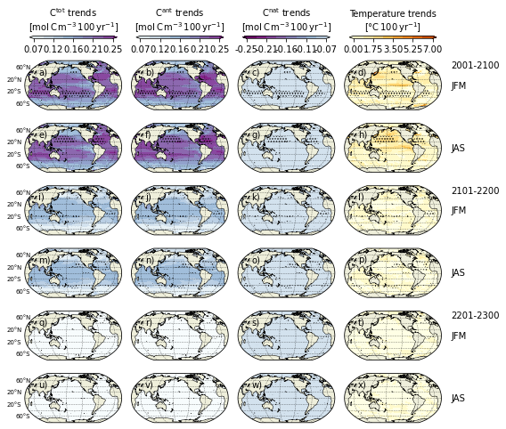

```python
%%time
%%memit
print(datetime.datetime.now())
print('Fig. 4: plot all terms')

#=========================================
# Load data2plot
#=========================================

savedfile = dirout+'data2plot-fig4.pckl'
with open(savedfile, 'rb') as f1: data2plot = pickle.load(f1)

#=========================================
# Parameters for data2plot
#=========================================

#period_list = list(data2plot['maps'].keys())
#season_list = list(data2plot[period_list[0]].keys())
period_list = ['2050', '2150', '2250']
season_list = ['JFM', 'JAS']
var_list = ['sdic-tot-sn-trd', 'sdic-ant-sn-trd', 'sdic-nat-sn-trd', 'stemp-trd']
nperiod = len(period_list)
nseason = len(season_list)
nvar  = len(var_list)

#=========================================
# Figure parameters
#=========================================

nrow, ncol = nperiod*nseason, nvar
ccrsproj = ccrs.Robinson(central_longitude=-155)

fsize = (nvar/(nperiod*nseason)*1.5*18*cm2in, 18*cm2in) # width, height
fig = plt.figure(figsize=fsize)

var_names = {'sdic-ant-sn-trd':'C$^{\mathrm{ant}}$ trends\n[mol$\,$C$\,$m$^{-3}$$\,$100$\,$yr$^{-1}$]',
             'sdic-tot-sn-trd':'C$^{\mathrm{tot}}$ trends\n[mol$\,$C$\,$m$^{-3}$$\,$100$\,$yr$^{-1}$]',
             'sdic-nat-sn-trd':'C$^{\mathrm{nat}}$ trends\n[mol$\,$C$\,$m$^{-3}$$\,$100$\,$yr$^{-1}$]',
             'stemp-trd' :'Temperature trends\n[°C$\,$100$\,$yr$^{-1}$]'}
period_names = {'2050': '2001-2100', '2150':'2101-2200', '2250':'2201-2300'}

subnum = list('abcdefghijklmnopqrstuvwxyz')
aaa=[]
for sss in subnum: aaa.append('a'+sss)
subnum=subnum+aaa
subnum.reverse()

#=========================================
# PLOTTING ARGS AND KWARGS
#=========================================

#---------------------
# Maps
#---------------------

kwmap = {}

a = cm.get_cmap('BuPu',64)
colors = a(np.linspace(0,1,10+2))[:-2]
newcmap = ListedColormap(colors[1:-1])
newcmap.set_under(colors[0])
newcmap.set_over(colors[-1])
kwmap['sdic-ant-sn-trd'] = dict(transform=ccrs.PlateCarree(), cmap=newcmap, vmin=.07, vmax=.25)
kwmap['sdic-tot-sn-trd'] = dict(transform=ccrs.PlateCarree(), cmap=newcmap, vmin=.07, vmax=.25)
a = cm.get_cmap('BuPu_r',64)
colors = a(np.linspace(0,1,10+2))[:-2]
newcmap = ListedColormap(colors[1:-1])
newcmap.set_under(colors[0])
newcmap.set_over(colors[-1])
kwmap['sdic-nat-sn-trd'] = dict(transform=ccrs.PlateCarree(), cmap=newcmap, vmin=-.25, vmax=-.07)

a = cm.get_cmap('YlOrBr',64)
colors = a(np.linspace(0,1,10+2))[:-2]
newcmap = ListedColormap(colors[1:-1])
newcmap.set_under(colors[0])
newcmap.set_over(colors[-1])
kwmap['stemp-trd'] = dict(transform=ccrs.PlateCarree(), cmap=newcmap, vmin=0, vmax=7)

#---------------------
# ACOD
#---------------------

dens = 4
kwaod = dict(transform=ccrs.PlateCarree(), colors='none', hatches=[dens*'.', dens*'.'])

#=========================================
# PLOT
#=========================================


pcm = []

for iperiod, vperiod in enumerate(period_list):

    for iseason, vseason in enumerate(season_list):

        for ivar, vvar in enumerate(var_list):

            irow = iseason + 2*iperiod
            iplot = irow*ncol+ivar+1
            zax = fig.add_subplot(nrow, ncol, iplot, projection=ccrsproj)

            #_____________________
            # var
            X1 = data2plot[vperiod][vseason][vvar]['X']
            Y1 = data2plot[vperiod][vseason][vvar]['Y']
            Z1 = data2plot[vperiod][vseason][vvar]['Z']*100
            zwpcm = zax.pcolormesh(X1, Y1, Z1, **kwmap[vvar])
            pcm.append(zwpcm)

            #_____________________
            # ACOD
            X1 = data2plot[vperiod][vseason]['ACOD']['X']
            Y1 = data2plot[vperiod][vseason]['ACOD']['Y']
            Z1 = data2plot[vperiod][vseason]['ACOD']['Z']
            zax.contourf(X1, Y1, Z1, levels = [0.5, 1.5], **kwaod)

            #_____________________
            # axis settings
            gl = add_gridlines_coastline_and_land(zax)
            if not ivar==0: gl.left_labels=False
        #
    #
#
fig.tight_layout()

ax = np.reshape(fig.axes, (nrow, ncol))
pcm = np.reshape(pcm, (nrow, ncol))

#=========================================
# numbering plots
#=========================================

for axrow in ax:
    for zax in axrow:
        zwtitle = subnum.pop() + ')'
        zax.annotate(zwtitle, (0.14, 0.72),xycoords='axes fraction')
    #
#

#=========================================
# Repositioning axis
#=========================================

for irow, axrow in enumerate(ax[1:]):
    for icol, zax in enumerate(axrow):
        zw1 = zax.get_position()
        ny0 = zw1.y0 + (irow+1)*0.2*zw1.height
        zax.set_position([zw1.x0, ny0, zw1.width, zw1.height])
    #
#

#=========================================
# Extra text
#=========================================

#---------------------
# On the right season titles
#---------------------

kwtxt = dict(fontsize='medium', rotation='horizontal', ha='left', va='center')
for iperiod, vperiod in enumerate(period_list):
    for iseason, vseason in enumerate(season_list):
        zw1 = ax[2*iperiod+iseason, -1].get_position()
        ny0 = 0.5 *(zw1.y0+zw1.y1)
        nx0 = zw1.x1 + .1*zw1.width
        fig.text(nx0, ny0, vseason, **kwtxt)
    #
#

#---------------------
# On the right period titles
#---------------------

kwtxt = dict(fontsize='medium', rotation='horizontal', ha='left', va='top')
for iperiod, vperiod in enumerate(period_list):
    zw1 = ax[2*iperiod, -1].get_position()
    ny0 = zw1.y1
    nx0 = zw1.x1 + .1*zw1.width
    fig.text(nx0, ny0, period_names[vperiod], **kwtxt)
#

#=========================================
# COLORBARS
#=========================================

for ivar, vvar in enumerate(var_list):

    zw1 = ax[0, ivar].get_position()
    nx0 = zw1.x0 +0.05*zw1.width
    ny0 = zw1.y1 + .45*zw1.height
    nw  = 0.9*zw1.width
    nh  = 0.03*nw
    cax = fig.add_axes([nx0, ny0, nw, nh])
    cbar = fig.colorbar(pcm[0, ivar], cax=cax, orientation='horizontal', ticklocation='bottom',
                        extend='both')
    cax.set_title(var_names[vvar], size='medium')
    ttt = np.linspace(kwmap[vvar]['vmin'], kwmap[vvar]['vmax'], int((pcm[0, 1].cmap.colors.shape[0]/2+1)))
    cbar.set_ticks(ttt)
    cbar.set_ticklabels(['%.2f' %s for s in ttt])
#

#=========================================
# Save figure
#=========================================

fignam = 'fig-4-allterms.png'
fig.savefig(dirout+fignam, bbox_inches='tight')
print('Done, figure saved: '+fignam)
```

### Plot

```
2023-10-11 11:55:15.307124
Fig. 4: plot
func: add_gridlines_coastline_and_land
func: add_gridlines_coastline_and_land
func: add_gridlines_coastline_and_land
func: add_gridlines_coastline_and_land
func: add_gridlines_coastline_and_land
func: add_gridlines_coastline_and_land
func: add_gridlines_coastline_and_land
func: add_gridlines_coastline_and_land
Done, figure saved: fig-4.png
CPU times: user 31.3 s, sys: 3.88 s, total: 35.2 s
Wall time: 30.7 s
```

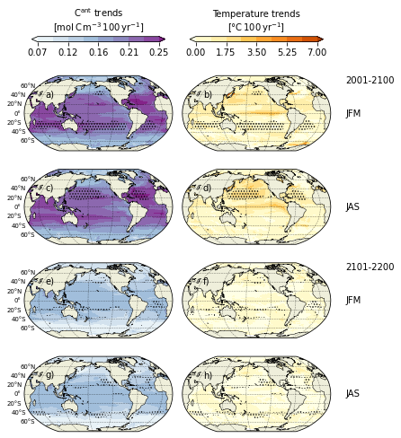

```python
%%time
print(datetime.datetime.now())
print('Fig. 4: plot')

#=========================================
# Load data2plot
#=========================================

savedfile = dirout+'data2plot-fig4.pckl'
with open(savedfile, 'rb') as f1: data2plot = pickle.load(f1)

#=========================================
# Parameters for data2plot
#=========================================

#period_list = list(data2plot['maps'].keys())
#season_list = list(data2plot[period_list[0]].keys())
period_list = ['2050', '2150']
season_list = ['JFM', 'JAS']
var_list = ['sdic-ant-sn-trd', 'stemp-trd']
nperiod = len(period_list)
nseason = len(season_list)
nvar  = len(var_list)

#=========================================
# Figure parameters
#=========================================

nrow, ncol = nperiod*nseason, nvar
ccrsproj = ccrs.Robinson(central_longitude=-155)

fsize = (nvar/(nperiod*nseason)*1.5*18*cm2in, 18*cm2in) # width, height
fig = plt.figure(figsize=fsize)

var_names = {'sdic-ant-sn-trd':'C$^{\mathrm{ant}}$ trends\n[mol$\,$C$\,$m$^{-3}$$\,$100$\,$yr$^{-1}$]',
             'sdic-tot-sn-trd':'C$^{\mathrm{tot}}$ trends\n[mol$\,$C$\,$m$^{-3}$$\,$100$\,$yr$^{-1}$]',
             'stemp-trd' :'Temperature trends\n[°C$\,$100$\,$yr$^{-1}$]'}
period_names = {'2050': '2001-2100', '2150':'2101-2200', '2250':'2201-2300'}

subnum = list('abcdefghijklmnopqrstuvwxyz')
aaa=[]
for sss in subnum: aaa.append('a'+sss)
subnum=subnum+aaa
subnum.reverse()

#=========================================
# PLOTTING ARGS AND KWARGS
#=========================================

#---------------------
# Maps
#---------------------

kwmap = {}

a = cm.get_cmap('BuPu',64)
colors = a(np.linspace(0,1,10+2))[:-2]
newcmap = ListedColormap(colors[1:-1])
newcmap.set_under(colors[0])
newcmap.set_over(colors[-1])
kwmap['sdic-ant-sn-trd'] = dict(transform=ccrs.PlateCarree(), cmap=newcmap, vmin=.07, vmax=.25)
kwmap['sdic-tot-sn-trd'] = dict(transform=ccrs.PlateCarree(), cmap=newcmap, vmin=.07, vmax=.25)

a = cm.get_cmap('YlOrBr',64)
colors = a(np.linspace(0,1,10+2))[:-2]
newcmap = ListedColormap(colors[1:-1])
newcmap.set_under(colors[0])
newcmap.set_over(colors[-1])
kwmap['stemp-trd'] = dict(transform=ccrs.PlateCarree(), cmap=newcmap, vmin=0, vmax=7)

#---------------------
# ACOD
#---------------------

dens = 4
kwaod = dict(transform=ccrs.PlateCarree(), colors='none', hatches=[dens*'.', dens*'.'])

#=========================================
# PLOT
#=========================================


pcm = []

for iperiod, vperiod in enumerate(period_list):

    for iseason, vseason in enumerate(season_list):

        for ivar, vvar in enumerate(var_list):

            irow = iseason + 2*iperiod
            iplot = irow*ncol+ivar+1
            zax = fig.add_subplot(nrow, ncol, iplot, projection=ccrsproj)

            #_____________________
            # var
            X1 = data2plot[vperiod][vseason][vvar]['X']
            Y1 = data2plot[vperiod][vseason][vvar]['Y']
            Z1 = data2plot[vperiod][vseason][vvar]['Z']*100
            zwpcm = zax.pcolormesh(X1, Y1, Z1, **kwmap[vvar])
            pcm.append(zwpcm)

            #_____________________
            # ACOD
            X1 = data2plot[vperiod][vseason]['ACOD']['X']
            Y1 = data2plot[vperiod][vseason]['ACOD']['Y']
            Z1 = data2plot[vperiod][vseason]['ACOD']['Z']
            zax.contourf(X1, Y1, Z1, levels = [0.5, 1.5], **kwaod)

            #_____________________
            # axis settings
            gl = add_gridlines_coastline_and_land(zax)
            if not ivar==0: gl.left_labels=False
        #
    #
#
fig.tight_layout()

ax = np.reshape(fig.axes, (nrow, ncol))
pcm = np.reshape(pcm, (nrow, ncol))

#=========================================
# numbering plots
#=========================================

for axrow in ax:
    for zax in axrow:
        zwtitle = subnum.pop() + ')'
        zax.annotate(zwtitle, (0.14, 0.72),xycoords='axes fraction')
    #
#

#=========================================
# Repositioning axis
#=========================================

for irow, axrow in enumerate(ax[1:]):
    for icol, zax in enumerate(axrow):
        zw1 = zax.get_position()
        ny0 = zw1.y0 + (irow+1)*0.2*zw1.height
        zax.set_position([zw1.x0, ny0, zw1.width, zw1.height])
    #
#

#=========================================
# Extra text
#=========================================

#---------------------
# On the right season titles
#---------------------

kwtxt = dict(fontsize='medium', rotation='horizontal', ha='left', va='center')
for iperiod, vperiod in enumerate(period_list):
    for iseason, vseason in enumerate(season_list):
        zw1 = ax[2*iperiod+iseason, -1].get_position()
        ny0 = 0.5 *(zw1.y0+zw1.y1)
        nx0 = zw1.x1 + .1*zw1.width
        fig.text(nx0, ny0, vseason, **kwtxt)
    #
#

#---------------------
# On the right period titles
#---------------------

kwtxt = dict(fontsize='medium', rotation='horizontal', ha='left', va='top')
for iperiod, vperiod in enumerate(period_list):
    zw1 = ax[2*iperiod, -1].get_position()
    ny0 = zw1.y1
    nx0 = zw1.x1 + .1*zw1.width
    fig.text(nx0, ny0, period_names[vperiod], **kwtxt)
#

#=========================================
# COLORBARS
#=========================================

for ivar, vvar in enumerate(var_list):

    zw1 = ax[0, ivar].get_position()
    nx0 = zw1.x0 +0.05*zw1.width
    ny0 = zw1.y1 + .45*zw1.height
    nw  = 0.9*zw1.width
    nh  = 0.03*nw
    cax = fig.add_axes([nx0, ny0, nw, nh])
    cbar = fig.colorbar(pcm[0, ivar], cax=cax, orientation='horizontal', ticklocation='bottom',
                        extend='both')
    cax.set_title(var_names[vvar], size='medium')
    ttt = np.linspace(kwmap[vvar]['vmin'], kwmap[vvar]['vmax'], int((pcm[0, 1].cmap.colors.shape[0]/2+1)))
    cbar.set_ticks(ttt)
    cbar.set_ticklabels(['%.2f' %s for s in ttt])
#

#=========================================
# Save figure
#=========================================

fignam = 'fig-4.png'
fig.savefig(dirout+fignam, bbox_inches='tight')
print('Done, figure saved: '+fignam)
```